# Análisis de enriquecimiento

Jaime Ñíguez Baeza

jaime.niguez@um.es

El apartado de enriquecimiento supone un paso clave en nuestro estudio ya que nos va a permitir evaluar la selección de predictores que se realizó en el paso de Machine Learning a partir de la identificación de aquellos término enriquecidos y su posible relación con la enfermedad de Parkinson.

El análisis de enriquecimiento se llevó a cabo de forma separada sobre cada uno de los subconjuntos de circRNA seleccionados en apartados anteriores, a los que se aplicó un análisis de sobrerepresentación (*ORA*) frente a las bases de datos de ontologías *Gene Ontology* (*GO*) (Biological process, Molecular Function y Cellular Com- ponent), *Kyoto Encyclopedia of Genes and Genomes* (KEGG pathway over-representation analysis y KEGG module over-representation analysis), *Disease Ontology Semantic and Enrichment* analysis (DOSE).

También se realizó un análisis de enriquecimiento basado en un ranking de genes mediante *Gene Set Enrichment Analysis* (*GSEA*), técnica que utiliza términos procedentes de distintas ontologías. El ranking se estableció para los modelos basados en Lasso a partir de los predictores ordenados de forma descendente por el valor de su coeficientes, mientras que para Random Forest se ordenaron de mayor a menor valor de importancia.

Las herramientas utilizadas en el desarrollo de esta parte del estudio fueron:

- [Yu G, Wang L-G, Han Y, et al. clusterProfiler: An r package for comparing biological themes among gene clusters. OMICS: A Journal of Integrative Biology 2012; 16: 284–287.](http://dx.doi.org/10.1089/omi.2011.0118)
- [Yu G, Wang L-G, Yan G-R, et al. DOSE: An r/bioconductor package for disease ontology semantic and enrichment analysis. Bioinformatics 2014; 31: 608–609.](http://dx.doi.org/10.1093/bioinformatics/btu684)

Además, para GSEA se utilizaron los datos de geneset de *MSigDB* para humano, los cuales se obtuvieron mediante la librería:

- [Dolgalev I (2022). *msigdbr: MSigDB Gene Sets for Multiple Organisms in a Tidy Data Format*. R package version 7.5.1, <https://CRAN.R-project.org/package=msigdbr>.](https://CRAN.R-project.org/package=msig%20dbr)

```r
Human_sets_all <- msigdbr(species = "Homo sapiens")
saveRDS(Human_sets_all, "Human_sets_all")
```

Para el proceso de enriquecimiento serán necesarias las siguientes librerías

```r
library(genefilter)
library(Biobase)
library(apeglm)
library(ashr)
library(clusterProfiler)
library(tikzDevice)
library(ggplot2)
library(DOSE)
library(kableExtra)
```

A continuación se exponen los distintos análisis de enriquecimiento y la representación de los resultados obtenidos.

# 1 Enriquecimiento circRNA procedentes de Lasso

En primer lugar se realizará el enriquecimiento a partir del conjunto de circRNA que fue seleccionado mediante el modelo basado en Lasso sin balanceo de las clases en los datos de entrada.

Para el enriquecimiento se utilizará el nombre del gen en formato Gene Symbol, por lo que tendremos que modificar nuestros predictores, eliminando el prefijo *circ*.

```r
predictoresLasso_Sort <- readRDS("../1. ML/predictoresLasso_sort")
predictoresLasso_Symbol <- sub("^circ", "",predictoresLasso_Sort$Predictores)
```

## 1.1 Enriquecimiento mediante la base de datos *Gene Ontology*

El análisis se realizará sobre todas las ontologías que componen la base de datos de *Gene Ontology*: *Biological Process*, *Molecular Function* y *Cellular Component*.

Podemos observar como en el resultado del análisis, en el que no se ha filtrado por ningún nivel de significación todavía, se obtiene un total de 150 términos, parte de los cuales contienen un $qvalue$ que los hace candidatos a ser seleccionados posteriormente (< 0.05).

```r
eGOLasso <- enrichGO(gene = predictoresLasso_Symbol,
                OrgDb = "org.Hs.eg.db",
                pvalueCutoff = 1,
                keyType = "SYMBOL",
                ont = "all"
                )
head(summary(as.data.frame(eGOLasso)))
```

```
##    ONTOLOGY              ID            Description         GeneRatio
##  Length:150         Length:150         Length:150         Length:150
##  Class :character   Class :character   Class :character   Class :character
##  Mode  :character   Mode  :character   Mode  :character   Mode  :character
##
##
##
##    BgRatio              pvalue             p.adjust             qvalue
##  Length:150         Min.   :0.0000013   Min.   :0.0004148   Min.   :0.0003821
##  Class :character   1st Qu.:0.0007942   1st Qu.:0.0949550   1st Qu.:0.0888081
##  Mode  :character   Median :0.0033495   Median :0.1358032   Median :0.1206447
##                     Mean   :0.0072118   Mean   :0.1274824   Mean   :0.1148014
##                     3rd Qu.:0.0110814   3rd Qu.:0.1683781   3rd Qu.:0.1467827
##                     Max.   :0.0330398   Max.   :0.2247640   Max.   :0.1970501
##     geneID              Count
##  Length:150         Min.   : 2.0
##  Class :character   1st Qu.: 3.0
##  Mode  :character   Median : 4.0
##                     Mean   : 5.5
##                     3rd Qu.: 8.0
##                     Max.   :18.0
```

Los términos enriquecidos se representan a continuación

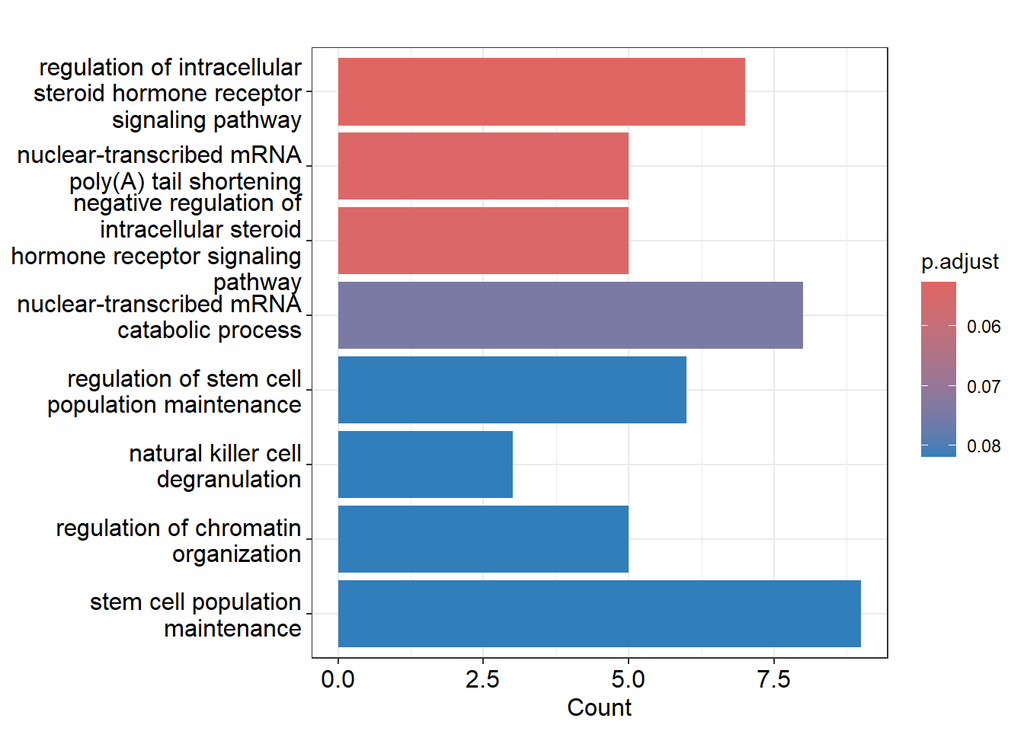

```r
barplot(eGOLasso)
```

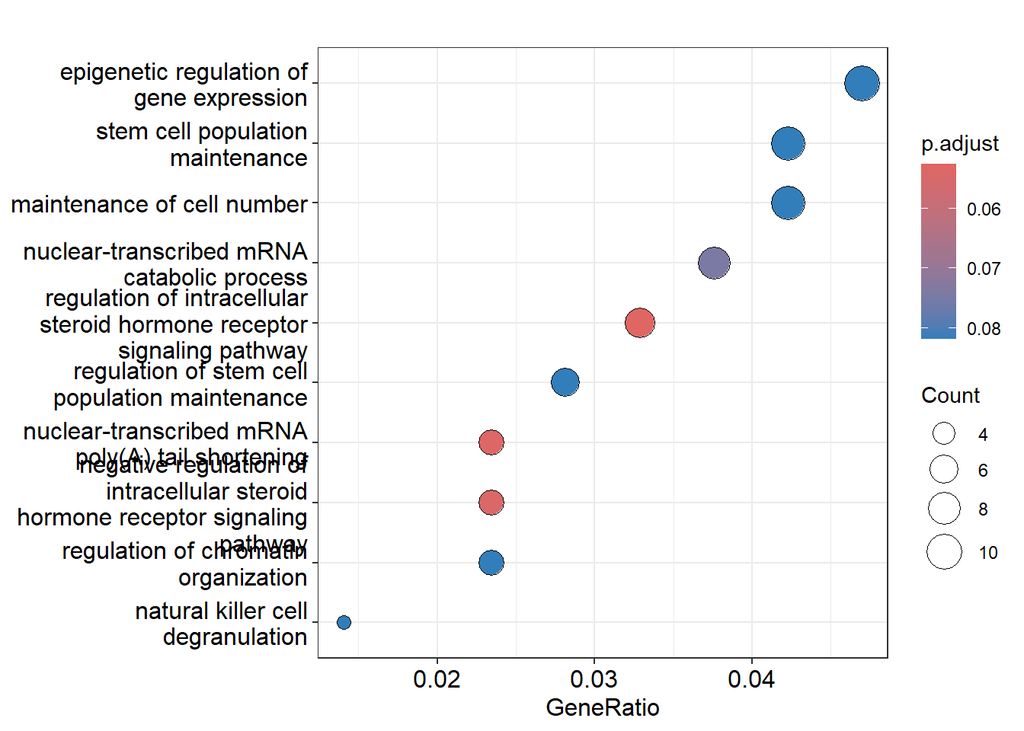

```r
clusterProfiler::dotplot(eGOLasso, orderBy="GeneRatio")
```

Y la lista completa de estos sería, la que queda a continuación, a la cual modificamos el campo que contiene los genes enriquecidos en cada término para facilitar futuros análisis y ordenamos ascendentemente por valor de $qvalue$. También se añadirán el modelo del que procede el conjunto de circRNA para poder evaluar más adelante su rendimiento.

```r
enriGO_genesLasso <- as.data.frame(eGOLasso)

GO_LASSO <- enriGO_genesLasso[order(enriGO_genesLasso$qvalue, decreasing = FALSE), ]
GO_LASSO$geneID <- gsub("/", " ", GO_LASSO$geneID, fixed = TRUE)
GO_LASSO$Model <- "LASSO"
```

```r
kbl(GO_LASSO, format = "html", row.names = FALSE)  %>%
kable_paper() %>%
  scroll_box(width = "100%", height = "500px")
```

| ONTOLOGY | ID | Description | GeneRatio | BgRatio | pvalue | p.adjust | qvalue | geneID | Count | Model |
| --- | --- | --- | --- | --- | --- | --- | --- | --- | --- | --- |
| CC | GO:0005769 | early endosome | 18/219 | 427/19886 | 0.0000013 | 0.0004148 | 0.0003821 | ERBB2 MGRN1 GGA3 RAB21 MON2 TPCN1 WASHC2A STX6 TBC1D2B ALS2 GPR107 LDLRAD4 INPP5B MARCHF8 RABGAP1L ZFYVE26 AP1G1 AP3D1 | 18 | LASSO |
| CC | GO:0034399 | nuclear periphery | 8/219 | 150/19886 | 0.0002626 | 0.0250071 | 0.0230328 | POLA1 NUP205 SMARCC1 AKAP8L SMARCD1 ATXN1 HNRNPM SMARCA4 | 8 | LASSO |
| CC | GO:0030014 | CCR4-NOT complex | 3/219 | 14/19886 | 0.0004384 | 0.0250071 | 0.0230328 | CNOT2 CNOT1 CNOT9 | 3 | LASSO |
| CC | GO:0071564 | npBAF complex | 3/219 | 14/19886 | 0.0004384 | 0.0250071 | 0.0230328 | SMARCC1 SMARCD1 SMARCA4 | 3 | LASSO |
| CC | GO:0140288 | GBAF complex | 3/219 | 14/19886 | 0.0004384 | 0.0250071 | 0.0230328 | SMARCC1 SMARCD1 SMARCA4 | 3 | LASSO |
| CC | GO:0016586 | RSC-type complex | 3/219 | 15/19886 | 0.0005436 | 0.0250071 | 0.0230328 | SMARCC1 SMARCD1 SMARCA4 | 3 | LASSO |
| CC | GO:0016363 | nuclear matrix | 7/219 | 128/19886 | 0.0005470 | 0.0250071 | 0.0230328 | POLA1 SMARCC1 AKAP8L SMARCD1 ATXN1 HNRNPM SMARCA4 | 7 | LASSO |
| CC | GO:0071565 | nBAF complex | 3/219 | 16/19886 | 0.0006636 | 0.0265452 | 0.0244495 | SMARCC1 SMARCD1 SMARCA4 | 3 | LASSO |
| MF | GO:0140993 | histone modifying activity | 10/216 | 202/18496 | 0.0001359 | 0.0455705 | 0.0397259 | KDM1A HDAC9 PADI4 UTY MIER2 NSD1 DOT1L SETBP1 KDM8 KAT6B | 10 | LASSO |
| MF | GO:0016922 | nuclear receptor binding | 8/216 | 137/18496 | 0.0002092 | 0.0455705 | 0.0397259 | CRY1 KDM1A CNOT1 MED4 MED1 NSD1 SMARCA4 MED14 | 8 | LASSO |
| MF | GO:0004535 | poly(A)-specific ribonuclease activity | 3/216 | 13/18496 | 0.0004120 | 0.0455705 | 0.0397259 | CNOT2 CNOT1 PARN | 3 | LASSO |
| MF | GO:0030374 | nuclear receptor coactivator activity | 5/216 | 55/18496 | 0.0004488 | 0.0455705 | 0.0397259 | KDM1A MED4 MED1 CNOT9 MED14 | 5 | LASSO |
| MF | GO:0003714 | transcription corepressor activity | 9/216 | 194/18496 | 0.0004717 | 0.0455705 | 0.0397259 | ATF7IP HDAC9 PHF12 MECP2 MIER2 MED1 NSD1 CASP8AP2 SMARCA4 | 9 | LASSO |
| MF | GO:0042809 | nuclear vitamin D receptor binding | 3/216 | 15/18496 | 0.0006443 | 0.0478995 | 0.0417562 | MED4 MED1 MED14 | 3 | LASSO |
| MF | GO:0140097 | catalytic activity, acting on DNA | 10/216 | 248/18496 | 0.0006942 | 0.0478995 | 0.0417562 | RFC2 FTO POLA1 FAN1 DMC1 XRCC1 FANCM MCM4 SMARCA4 EXO1 | 10 | LASSO |
| CC | GO:0031901 | early endosome membrane | 8/219 | 195/19886 | 0.0014709 | 0.0522999 | 0.0481710 | GGA3 RAB21 MON2 TPCN1 WASHC2A LDLRAD4 INPP5B MARCHF8 | 8 | LASSO |
| BP | GO:0033143 | regulation of intracellular steroid hormone receptor signaling pathway | 7/213 | 73/18870 | 0.0000183 | 0.0526218 | 0.0492154 | CRY1 KDM1A CNOT2 CNOT1 MED1 CNOT9 SMARCA4 | 7 | LASSO |
| BP | GO:0000289 | nuclear-transcribed mRNA poly(A) tail shortening | 5/213 | 34/18870 | 0.0000373 | 0.0534741 | 0.0500124 | CNOT2 CNOT1 TNRC6A CNOT9 PARN | 5 | LASSO |
| BP | GO:0033144 | negative regulation of intracellular steroid hormone receptor signaling pathway | 5/213 | 37/18870 | 0.0000568 | 0.0543310 | 0.0508139 | CRY1 CNOT2 CNOT1 CNOT9 SMARCA4 | 5 | LASSO |
| MF | GO:0032451 | demethylase activity | 4/216 | 40/18496 | 0.0011892 | 0.0717966 | 0.0625883 | KDM1A FTO UTY KDM8 | 4 | LASSO |
| BP | GO:0000956 | nuclear-transcribed mRNA catabolic process | 8/213 | 128/18870 | 0.0001037 | 0.0743698 | 0.0695555 | EDC3 RNPS1 CNOT2 CNOT1 TNRC6A HBS1L CNOT9 PARN | 8 | LASSO |
| BP | GO:2000036 | regulation of stem cell population maintenance | 6/213 | 74/18870 | 0.0001885 | 0.0818810 | 0.0765804 | CNOT2 CNOT1 SMARCC1 SAV1 SMARCD1 SMARCA4 | 6 | LASSO |
| BP | GO:0043320 | natural killer cell degranulation | 3/213 | 11/18870 | 0.0002189 | 0.0818810 | 0.0765804 | LAMP1 RAB27A AP1G1 | 3 | LASSO |
| BP | GO:1902275 | regulation of chromatin organization | 5/213 | 49/18870 | 0.0002226 | 0.0818810 | 0.0765804 | TLK2 KDM1A ATF7IP PHF20 L3MBTL3 | 5 | LASSO |
| BP | GO:0019827 | stem cell population maintenance | 9/213 | 183/18870 | 0.0002400 | 0.0818810 | 0.0765804 | CNOT2 PADI4 CNOT1 SMARCC1 SAV1 SMARCD1 SMARCA4 MED14 BRAF | 9 | LASSO |
| BP | GO:0098727 | maintenance of cell number | 9/213 | 187/18870 | 0.0002817 | 0.0818810 | 0.0765804 | CNOT2 PADI4 CNOT1 SMARCC1 SAV1 SMARCD1 SMARCA4 MED14 BRAF | 9 | LASSO |
| BP | GO:0040029 | epigenetic regulation of gene expression | 10/213 | 229/18870 | 0.0002853 | 0.0818810 | 0.0765804 | KDM1A ATF7IP HDAC9 PHF20 MECP2 TASOR2 L3MBTL3 DOT1L SMARCD1 SMARCA4 | 10 | LASSO |
| MF | GO:0003713 | transcription coactivator activity | 10/216 | 280/18496 | 0.0017311 | 0.0928998 | 0.0809849 | KDM1A MED4 MED1 SMARCC1 SMARCD1 CNOT9 MTDH SMARCA4 MED14 KAT6B | 10 | LASSO |
| CC | GO:0070847 | core mediator complex | 3/219 | 26/19886 | 0.0028412 | 0.0909187 | 0.0837409 | MED4 MED1 MED14 | 3 | LASSO |
| BP | GO:0006900 | vesicle budding from membrane | 6/213 | 84/18870 | 0.0003768 | 0.0948755 | 0.0887337 | TRAPPC8 SEC24A SCAP AP1G1 AP3D1 VAPA | 6 | LASSO |

[output cut: 120 more lines]

## 1.2 Enriquecimiento mediante la base de datos KEGG

El proceso para el enriquecimiento con la base de datos *KEGG* requiere un paso previo en el que traducimos el nombre de nuestros circRNA de Gene Symbol a EntrezID (*NCBI* id) para poder utilizarlos como datos de entrada de la función.

Parte de estos datos (2,94%) no pudieron ser identificados según su EntrezID, por lo que no se utilizaron en el proceso de enriquecimiento.

El resto del proceso se realiza de manera similar al que se vió anteriormente.

```r
Lasso.bitr <- bitr(predictoresLasso_Symbol, fromType = "SYMBOL",
                toType = "ENTREZID",
                OrgDb = "org.Hs.eg.db")
Lasso.EntrezID <- Lasso.bitr$ENTREZID
```

```r
enrichKEGGLasso <- enrichKEGG(gene = Lasso.EntrezID,
                 organism     = "hsa",
                 qvalueCutoff = 1.0,
                 keyType = "ncbi-geneid")
```

El resultado obtenido es de un solo término, *RNA degradation*, el cual es significativo.

Para utilziar el mismo formato que con el resto de enriquecimientos, realizamos la traducción de los EntrezID a Gene Symbol.

```r
Kegg_genesLasso <- as.data.frame(enrichKEGGLasso)

# Añadimos una columna con los Symbol:
for (i in 1:nrow(Kegg_genesLasso)) {
  GenesKeggLasso <- unlist(strsplit(Kegg_genesLasso[i, "geneID"], "/"))
  GenesKeggLasso_Symbol <- as.list(Lasso.bitr[Lasso.bitr$ENTREZID %in% GenesKeggLasso, "SYMBOL"])
  Kegg_genesLasso[i, "geneID"] <- paste(GenesKeggLasso_Symbol, collapse = " ")
}

Kegg_genesLasso <- Kegg_genesLasso[order(Kegg_genesLasso$qvalue, decreasing = FALSE), ]
Kegg_genesLasso$Model <- "Lasso"

kbl(Kegg_genesLasso, format = "html", row.names = FALSE)  %>%
kable_paper() %>%
  scroll_box(width = "100%", height = "150px")
```

| category | subcategory | ID | Description | GeneRatio | BgRatio | pvalue | p.adjust | qvalue | geneID | Count | Model |
| --- | --- | --- | --- | --- | --- | --- | --- | --- | --- | --- | --- |
| Genetic Information Processing | Folding, sorting and degradation | hsa03018 | RNA degradation | 7/112 | 79/8659 | 6.75e-05 | 0.012495 | 0.012495 | EDC3 PFKP CNOT2 CNOT1 CNOT9 PABPC1L PARN | 7 | Lasso |

## 1.3 Enriquecimiento mediante la base de datos de módulos KEGG (MKEGG)

El proceso para el enriquecimiento de módulos de KEGG se realiza de igual manera que el anterior, obteniéndose 5 términos.

```r
enrichMKEGG.Lasso <- enrichMKEGG(gene = Lasso.EntrezID,
                   organism = 'hsa',
                   pvalueCutoff = 1.0,
                   keyType = "ncbi-geneid")
enrichMKEGG.Lasso
```

```
##       ID            Description         GeneRatio           BgRatio
##  Length:5           Length:5           Length:5           Length:5
##  Class :character   Class :character   Class :character   Class :character
##  Mode  :character   Mode  :character   Mode  :character   Mode  :character
##
##
##
##      pvalue            p.adjust           qvalue           geneID
##  Min.   :0.008616   Min.   :0.04308   Min.   :0.03628   Length:5
##  1st Qu.:0.090180   1st Qu.:0.15526   1st Qu.:0.13075   Class :character
##  Median :0.115807   Median :0.15526   Median :0.13075   Mode  :character
##  Mean   :0.111703   Mean   :0.14571   Mean   :0.12271
##  3rd Qu.:0.124208   3rd Qu.:0.15526   3rd Qu.:0.13075
##  Max.   :0.219705   Max.   :0.21971   Max.   :0.18502
##      Count
##  Min.   :1.0
##  1st Qu.:1.0
##  Median :1.0
##  Mean   :1.2
##  3rd Qu.:1.0
##  Max.   :2.0
```

De estos términos, uno de ellos es significativo, conteniendo dos genes enriquecidos.

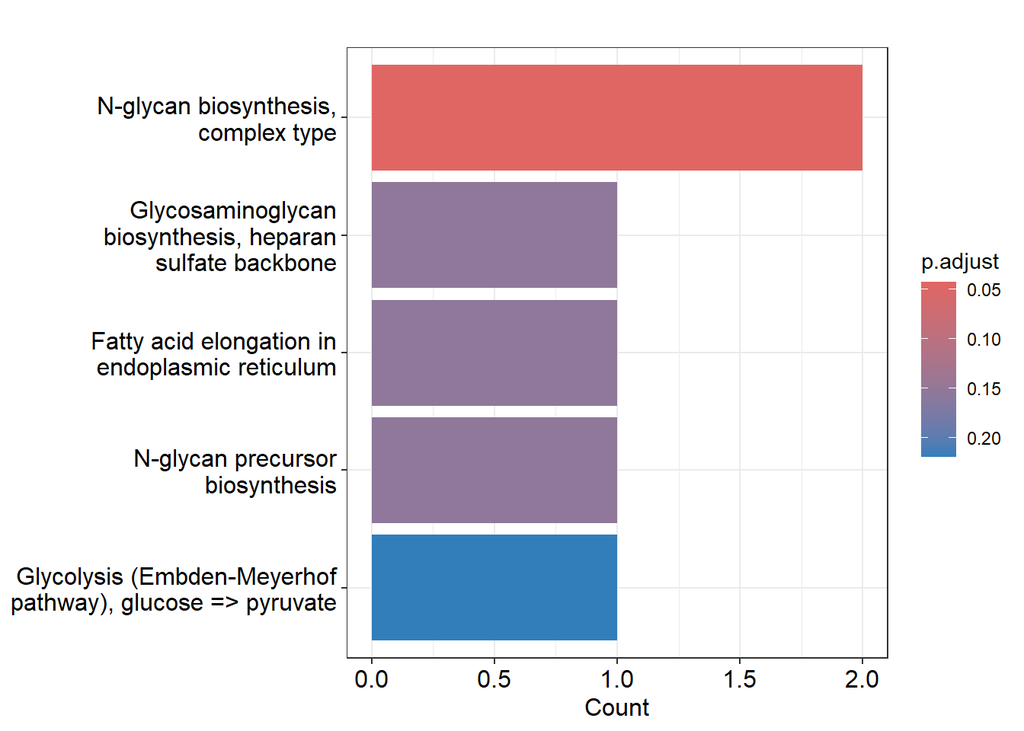

```r
barplot(enrichMKEGG.Lasso)
```

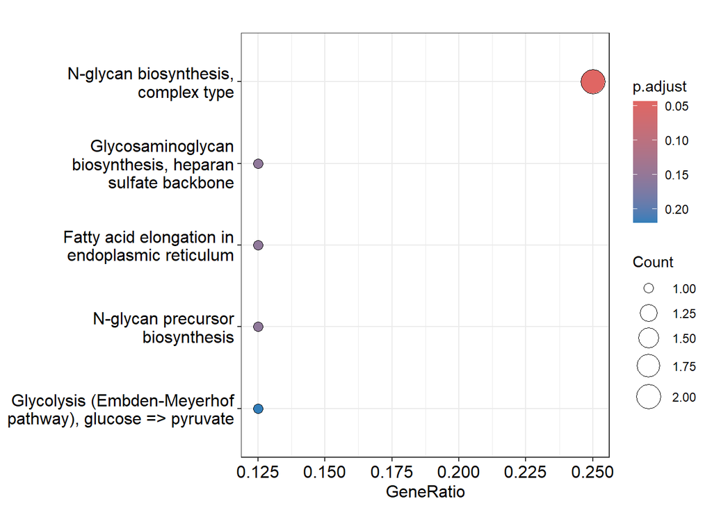

```r
clusterProfiler::dotplot(enrichMKEGG.Lasso, orderBy="GeneRatio")
```

Se lleva a cabo el proceso de traducción de EntreID a Gene Symbol de igual manera que anteriormente y se añade el modelo del que proceden los datos.

```r
MKEGG_genesLasso <- as.data.frame(enrichMKEGG.Lasso)

# Añadimos una columna con los Symbol:
for (i in 1:nrow(MKEGG_genesLasso)) {
  GenesMKeggLasso <- unlist(strsplit(MKEGG_genesLasso[i, "geneID"], "/"))
  GenesMKeggLasso_Symbol <- as.list(Lasso.bitr[Lasso.bitr$ENTREZID %in% GenesMKeggLasso, "SYMBOL"])
  MKEGG_genesLasso[i, "geneID"] <- paste(GenesMKeggLasso_Symbol, collapse = " ")
}

MKEGG_genesLasso <- MKEGG_genesLasso[order(MKEGG_genesLasso$qvalue, decreasing = FALSE), ]
MKEGG_genesLasso$Model <- "Lasso"


kbl(MKEGG_genesLasso, format = "html", row.names = FALSE)  %>%
kable_paper() %>%
  scroll_box(width = "100%", height = "300px")
```

| ID | Description | GeneRatio | BgRatio | pvalue | p.adjust | qvalue | geneID | Count | Model |
| --- | --- | --- | --- | --- | --- | --- | --- | --- | --- |
| M00075 | N-glycan biosynthesis, complex type | 2/8 | 16/855 | 0.0086162 | 0.0430808 | 0.0362786 | ST6GAL2 FUT8 | 2 | Lasso |
| M00059 | Glycosaminoglycan biosynthesis, heparan sulfate backbone | 1/8 | 10/855 | 0.0901801 | 0.1552602 | 0.1307455 | EXTL3 | 1 | Lasso |
| M00415 | Fatty acid elongation in endoplasmic reticulum | 1/8 | 13/855 | 0.1158073 | 0.1552602 | 0.1307455 | HACD1 | 1 | Lasso |
| M00055 | N-glycan precursor biosynthesis | 1/8 | 14/855 | 0.1242082 | 0.1552602 | 0.1307455 | ALG8 | 1 | Lasso |
| M00001 | Glycolysis (Embden-Meyerhof pathway), glucose => pyruvate | 1/8 | 26/855 | 0.2197054 | 0.2197054 | 0.1850151 | PFKP | 1 | Lasso |

## 1.4 Enriquecimiento mediante la base de datos Disease Ontology (DO)

Para el enriquecimiento DOSE se obtuvieron también 5 términos enriquecidos, los cuales podemos observar que no incluyen ninguno con $qvalue$ significativo.

```r
eDOLasso <- enrichDO(gene          = Lasso.EntrezID,
              ont           = "DO",
              pvalueCutoff  = 0.1,
              pAdjustMethod = "BH",
              minGSSize     = 1,
              maxGSSize     = 500,
              qvalueCutoff  = 0.1,
              readable      = FALSE)
```

```r
eDOLasso <- as.data.frame(eDOLasso)

# Añadimos una columna con los Symbol:
for (i in 1:nrow(eDOLasso)) {
  GeneseDOLasso <- unlist(strsplit(eDOLasso[i, "geneID"], "/"))
  GeneseDOLasso_Symbol <- as.list(Lasso.bitr[Lasso.bitr$ENTREZID %in% GeneseDOLasso, "SYMBOL"])
  eDOLasso[i, "geneID"] <- paste(GeneseDOLasso_Symbol, collapse = " ")
}


eDOLasso <- eDOLasso[order(eDOLasso$qvalue, decreasing = FALSE), ]
eDOLasso$Model <- "LASSO"

kbl(eDOLasso, format = "html", row.names = FALSE) %>%
kable_paper() %>%
  scroll_box(width = "100%", height = "200px")
```

| ID | Description | GeneRatio | BgRatio | pvalue | p.adjust | qvalue | geneID | Count | Model |
| --- | --- | --- | --- | --- | --- | --- | --- | --- | --- |
| DOID:0110155 | Charcot-Marie-Tooth disease type 2A2A | 2/142 | 2/10312 | 0.0001883 | 0.0692024 | 0.059465 |  | 2 | LASSO |
| DOID:0111557 | Charcot-Marie-Tooth disease type 2A2B | 2/142 | 2/10312 | 0.0001883 | 0.0692024 | 0.059465 |  | 2 | LASSO |
| DOID:1925 | Coffin-Siris syndrome | 3/142 | 12/10312 | 0.0005135 | 0.0822911 | 0.070712 |  | 3 | LASSO |
| DOID:0060539 | Hermansky-Pudlak syndrome 1 | 2/142 | 3/10312 | 0.0005598 | 0.0822911 | 0.070712 |  | 2 | LASSO |
| DOID:0060690 | autosomal dominant auditory neuropathy 1 | 2/142 | 3/10312 | 0.0005598 | 0.0822911 | 0.070712 |  | 2 | LASSO |

## 1.5 Enriquecimiento mediante GSEA

EL enriquecimiento mediante la técnica Gene Set Enrichment Analysis va a hacer uso de la base de datos *Molecular Signatures Database* (MSigDB) para genes humanos, la cual se descargó al comienzo de este documento.

Además de esto, para GSEA se va a generar un ranking de los genes según su coeficientes, de manera que los coeficientes positivos más altos indicarán una relación más fuerte con la condición positiva de nuestro estudio (*Case*), mientras que los más negativos indicarán una relación más importante con la condición negativa (*Control*). Este ranking formará un vector en el que el Gene Symbol será el nombre de los coeficientes.

```r
hs_sets <- readRDS("Human_sets_all")

predictoresLassoGSEA <- predictoresLasso_Sort
predictoresLassoGSEA <- arrange(predictoresLassoGSEA, desc(coeficientes))

vectorLassoGSEA <- predictoresLassoGSEA$coeficientes; names(vectorLassoGSEA) <- predictoresLassoGSEA$Predictores
names(vectorLassoGSEA) <- sub("^circ", "", names(vectorLassoGSEA))
```

```r
vectorLassoGSEA[1:10]
```

```
##      MFN2     ERBB2     NCF1C      EDC3      RFC2     MLYCD     EXTL3      MFN1
## 0.2679364 0.2507463 0.2356374 0.2275681 0.2079059 0.1571992 0.1535734 0.1439356
##     DDX50     MGRN1
## 0.1429521 0.1399368
```

Debido al alto número de términos obtenidos, para este análisis se realizó un filtrado previo estableciendo un umbral de $qvalue$ de 0.5 o superior. Como resultado se obtuvieron 280 términos.

```r
gsea_resultsLasso <- GSEA(
  geneList = vectorLassoGSEA, # Ordered ranked gene list
  minGSSize = 1, # Minimum gene set size
  pvalueCutoff = 0.5,
  eps = 0, # Boundary for calculating the p value
  seed = FALSE, # Set seed to make results reproducible
  pAdjustMethod = "BH", # Benjamini-Hochberg correction
  TERM2GENE = dplyr::select(
    hs_sets,
    gs_name,
    gene_symbol
  )
)
```

Los resultados obtenidos no obstante no presentan ningún resultado significativo, por lo que serán filtrados en el proceso posterior de selección de términos relevantes.

```r
GSEA_LassoTotal <- as.data.frame(gsea_resultsLasso)

GSEA_Lasso <- GSEA_LassoTotal[order(GSEA_LassoTotal$qvalue, decreasing = FALSE), ]

GSEA_Lasso$core_enrichment <- gsub("/", " ", GSEA_Lasso$core_enrichment, fixed = TRUE)

GSEA_Lasso$Model <- "LASSO"

kbl(GSEA_Lasso, format = "html", row.names = FALSE) %>%
kable_paper() %>%
  scroll_box(width = "100%", height = "500px")
```

| ID | Description | setSize | enrichmentScore | NES | pvalue | p.adjust | qvalue | rank | leading_edge | core_enrichment | Model |
| --- | --- | --- | --- | --- | --- | --- | --- | --- | --- | --- | --- |
| GOCC_MEMBRANE_PROTEIN_COMPLEX | GOCC_MEMBRANE_PROTEIN_COMPLEX | 15 | 0.7650034 | 2.051652 | 0.0001396 | 0.4896584 | 0.4842767 | 20 | tags=47%, list=8%, signal=46% | ERBB2 NCF1C MFN1 SEC24A RIPK1 CLIC2 CATSPERG | LASSO |
| GOMF_RIBONUCLEOTIDE_BINDING | GOMF_RIBONUCLEOTIDE_BINDING | 38 | 0.5718048 | 1.956684 | 0.0005102 | 0.4896584 | 0.4842767 | 40 | tags=39%, list=17%, signal=39% | MFN2 ERBB2 RFC2 MFN1 DDX50 PFKP PAK2 HSPA4 MAST3 RIPK1 STK39 MAP3K4 ABCB7 UBE2I ATP8B4 | LASSO |
| HP_REGIONAL_ABNORMALITY_OF_SKIN | HP_REGIONAL_ABNORMALITY_OF_SKIN | 10 | 0.8036004 | 1.909542 | 0.0004286 | 0.4896584 | 0.4842767 | 7 | tags=20%, list=3%, signal=20% | RFC2 EXTL3 | LASSO |
| HP_ABNORMAL_DERMATOGLYPHICS | HP_ABNORMAL_DERMATOGLYPHICS | 8 | 0.8376925 | 1.873924 | 0.0005802 | 0.4896584 | 0.4842767 | 7 | tags=25%, list=3%, signal=25% | RFC2 EXTL3 | LASSO |
| HP_NAUSEA_AND_VOMITING | HP_NAUSEA_AND_VOMITING | 9 | 0.8018901 | 1.860075 | 0.0006009 | 0.4896584 | 0.4842767 | 6 | tags=33%, list=3%, signal=34% | ERBB2 RFC2 MLYCD | LASSO |
| GSE13547_CTRL_VS_ANTI_IGM_STIM_BCELL_12H_UP | GSE13547_CTRL_VS_ANTI_IGM_STIM_BCELL_12H_UP | 6 | -0.9039116 | -1.842680 | 0.0002266 | 0.4896584 | 0.4842767 | 17 | tags=67%, list=7%, signal=64% | DEPDC1 TPX2 RNASEH2B CPT1A | LASSO |
| MORF_FANCG | MORF_FANCG | 5 | 0.9218939 | 1.791402 | 0.0003634 | 0.4896584 | 0.4842767 | 7 | tags=40%, list=3%, signal=40% | MFN2 EXTL3 | LASSO |
| MORF_FDXR | MORF_FDXR | 5 | 0.9218939 | 1.791402 | 0.0003634 | 0.4896584 | 0.4842767 | 7 | tags=40%, list=3%, signal=40% | MFN2 EXTL3 | LASSO |
| GOCC_PLASMA_MEMBRANE_PROTEIN_COMPLEX | GOCC_PLASMA_MEMBRANE_PROTEIN_COMPLEX | 5 | 0.9116251 | 1.771448 | 0.0006022 | 0.4896584 | 0.4842767 | 20 | tags=80%, list=8%, signal=75% | ERBB2 NCF1C RIPK1 CATSPERG | LASSO |
| KEGG_FOCAL_ADHESION | KEGG_FOCAL_ADHESION | 5 | 0.9084944 | 1.765364 | 0.0006962 | 0.4896584 | 0.4842767 | 12 | tags=40%, list=5%, signal=39% | ERBB2 PAK2 | LASSO |
| WP_FOCAL_ADHESION | WP_FOCAL_ADHESION | 5 | 0.9084944 | 1.765364 | 0.0006962 | 0.4896584 | 0.4842767 | 12 | tags=40%, list=5%, signal=39% | ERBB2 PAK2 | LASSO |
| HP_ABNORMALITY_OF_DENTAL_MORPHOLOGY | HP_ABNORMALITY_OF_DENTAL_MORPHOLOGY | 4 | 0.9480268 | 1.730558 | 0.0003959 | 0.4896584 | 0.4842767 | 5 | tags=25%, list=2%, signal=25% | RFC2 | LASSO |
| MORF_DDB1 | MORF_DDB1 | 4 | 0.9468210 | 1.728357 | 0.0004298 | 0.4896584 | 0.4842767 | 7 | tags=50%, list=3%, signal=49% | MFN2 EXTL3 | LASSO |
| HP_SKIN_DIMPLE | HP_SKIN_DIMPLE | 4 | 0.9356393 | 1.707945 | 0.0008638 | 0.4896584 | 0.4842767 | 7 | tags=50%, list=3%, signal=49% | RFC2 EXTL3 | LASSO |
| HP_ABNORMAL_ATRIOVENTRICULAR_VALVE_MORPHOLOGY | HP_ABNORMAL_ATRIOVENTRICULAR_VALVE_MORPHOLOGY | 4 | 0.9337914 | 1.704572 | 0.0009151 | 0.4896584 | 0.4842767 | 18 | tags=75%, list=8%, signal=71% | RFC2 EXTL3 CLIC2 | LASSO |
| HP_MITRAL_VALVE_PROLAPSE | HP_MITRAL_VALVE_PROLAPSE | 4 | 0.9337914 | 1.704572 | 0.0009151 | 0.4896584 | 0.4842767 | 18 | tags=75%, list=8%, signal=71% | RFC2 EXTL3 CLIC2 | LASSO |
| HP_PROPORTIONATE_SHORT_STATURE | HP_PROPORTIONATE_SHORT_STATURE | 3 | -0.9640599 | -1.651833 | 0.0010051 | 0.4896584 | 0.4842767 | 7 | tags=67%, list=3%, signal=66% | BRAF SON | LASSO |
| HP_SUBMUCOUS_CLEFT_OF_SOFT_AND_HARD_PALATE | HP_SUBMUCOUS_CLEFT_OF_SOFT_AND_HARD_PALATE | 3 | -0.9640599 | -1.651833 | 0.0010051 | 0.4896584 | 0.4842767 | 7 | tags=67%, list=3%, signal=66% | BRAF SON | LASSO |
| HP_ADDUCTED_THUMB | HP_ADDUCTED_THUMB | 3 | 0.9711617 | 1.632593 | 0.0006067 | 0.4896584 | 0.4842767 | 5 | tags=67%, list=2%, signal=66% | ERBB2 RFC2 | LASSO |
| HP_NEVUS | HP_NEVUS | 3 | 0.9696958 | 1.630129 | 0.0006776 | 0.4896584 | 0.4842767 | 5 | tags=33%, list=2%, signal=33% | RFC2 | LASSO |
| HP_ARTHRALGIA | HP_ARTHRALGIA | 3 | 0.9690152 | 1.628985 | 0.0007042 | 0.4896584 | 0.4842767 | 5 | tags=67%, list=2%, signal=66% | MFN2 RFC2 | LASSO |
| GOMF_ACYLTRANSFERASE_ACTIVITY | GOMF_ACYLTRANSFERASE_ACTIVITY | 2 | -0.9948809 | -1.541036 | 0.0004769 | 0.4896584 | 0.4842767 | 2 | tags=100%, list=1%, signal=100% | CPT1A | LASSO |
| MIR1278 | MIR1278 | 2 | -0.9915254 | -1.535838 | 0.0007886 | 0.4896584 | 0.4842767 | 5 | tags=100%, list=2%, signal=99% | RUFY2 | LASSO |
| HP_SLOW_DECREASE_IN_VISUAL_ACUITY | HP_SLOW_DECREASE_IN_VISUAL_ACUITY | 2 | 0.9963677 | 1.517501 | 0.0004283 | 0.4896584 | 0.4842767 | 1 | tags=50%, list=0%, signal=50% | MFN2 | LASSO |
| HP_ALVEOLAR_CELL_CARCINOMA | HP_ALVEOLAR_CELL_CARCINOMA | 2 | 0.9918823 | 1.510670 | 0.0010099 | 0.4896584 | 0.4842767 | 2 | tags=50%, list=1%, signal=50% | ERBB2 | LASSO |
| HP_LUNG_ADENOCARCINOMA | HP_LUNG_ADENOCARCINOMA | 2 | 0.9918823 | 1.510670 | 0.0010099 | 0.4896584 | 0.4842767 | 2 | tags=50%, list=1%, signal=50% | ERBB2 | LASSO |
| HP_NEOPLASM_OF_THE_TRACHEOBRONCHIAL_SYSTEM | HP_NEOPLASM_OF_THE_TRACHEOBRONCHIAL_SYSTEM | 2 | 0.9918823 | 1.510670 | 0.0010099 | 0.4896584 | 0.4842767 | 2 | tags=50%, list=1%, signal=50% | ERBB2 | LASSO |
| KEGG_BLADDER_CANCER | KEGG_BLADDER_CANCER | 2 | 0.9918823 | 1.510670 | 0.0010099 | 0.4896584 | 0.4842767 | 2 | tags=50%, list=1%, signal=50% | ERBB2 | LASSO |
| KEGG_ENDOMETRIAL_CANCER | KEGG_ENDOMETRIAL_CANCER | 2 | 0.9918823 | 1.510670 | 0.0010099 | 0.4896584 | 0.4842767 | 2 | tags=50%, list=1%, signal=50% | ERBB2 | LASSO |
| KEGG_NON_SMALL_CELL_LUNG_CANCER | KEGG_NON_SMALL_CELL_LUNG_CANCER | 2 | 0.9918823 | 1.510670 | 0.0010099 | 0.4896584 | 0.4842767 | 2 | tags=50%, list=1%, signal=50% | ERBB2 | LASSO |

[output cut: 250 more lines]

# 2 Enriquecimiento circRNA procedentes de Lasso + Oversampling

El proceso de enriquecimiento a partir del conjunto de predictores que fueron seleccionados mediante el modelo de Lasso con oversampling se realizará de manera idéntica al visto para el modelo Lasso anterior.

```r
predictoresLasso_Over <- readRDS("../1. ML/predictoresLasso.over")
predictoresLassoOver_Symbol <- sub("^circ", "",predictoresLasso_Over$Predictores)
```

## 2.1 Enriquecimiento mediante la base de datos *Gene Ontology*

En este caso la cantidad de términos obtenidos es de 82, significativos y no significativos.

```r
eGOLassoOver <- enrichGO(gene = predictoresLassoOver_Symbol,
                OrgDb = "org.Hs.eg.db",
                pvalueCutoff = 1,
                keyType = "SYMBOL",
                ont = "all"
                )
head(summary(as.data.frame(eGOLassoOver)))
```

```
##    ONTOLOGY              ID            Description         GeneRatio
##  Length:82          Length:82          Length:82          Length:82
##  Class :character   Class :character   Class :character   Class :character
##  Mode  :character   Mode  :character   Mode  :character   Mode  :character
##
##
##
##    BgRatio              pvalue             p.adjust            qvalue
##  Length:82          Min.   :5.685e-06   Min.   :0.002718   Min.   :0.002418
##  Class :character   1st Qu.:4.390e-04   1st Qu.:0.069687   1st Qu.:0.064009
##  Mode  :character   Median :1.818e-03   Median :0.138796   Median :0.133261
##                     Mean   :4.734e-03   Mean   :0.118996   Mean   :0.109452
##                     3rd Qu.:9.952e-03   3rd Qu.:0.159865   3rd Qu.:0.142227
##                     Max.   :2.019e-02   Max.   :0.214418   Max.   :0.190761
##     geneID              Count
##  Length:82          Min.   : 2.000
##  Class :character   1st Qu.: 3.000
##  Mode  :character   Median : 5.500
##                     Mean   : 6.146
##                     3rd Qu.: 8.750
##                     Max.   :16.000
```

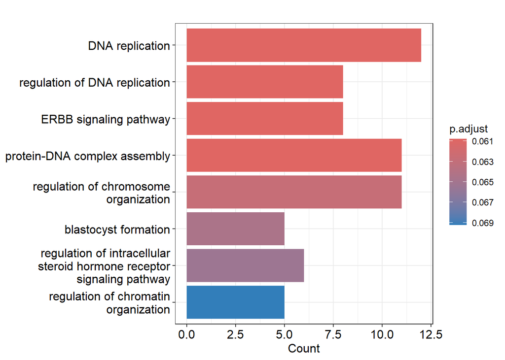

```r
barplot(eGOLassoOver)
```

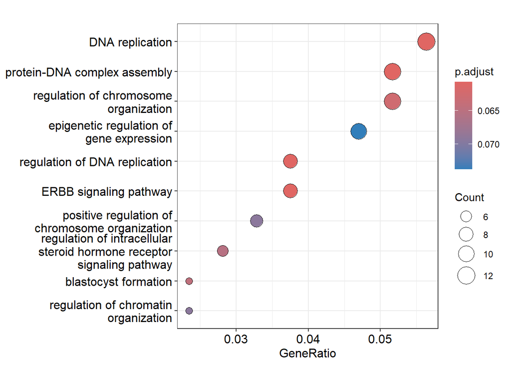

```r
clusterProfiler::dotplot(eGOLassoOver, orderBy="GeneRatio")
```

```r
enriGO_genesLassoOv <- as.data.frame(eGOLassoOver)

GO_LASSO_Ov <- enriGO_genesLassoOv[order(enriGO_genesLassoOv$qvalue, decreasing = FALSE), ]
GO_LASSO_Ov$geneID <- gsub("/", " ", GO_LASSO_Ov$geneID, fixed = TRUE)
GO_LASSO_Ov$Model <- "LASSO OV"
```

Entre los resultados se encuentran términos no enriquecidos en el modelo Lasso que podrían guardar una relación con la enfermedad de Parkinson, tales como la función molecular *phosphatidylinositol-3,5-bisphosphate binding* y algunos redundantes como el componente celular *early endosome*.

Estos resultados refuerzan la decisión de haber escogido ambos modelos para el análisis, ya que parecen contener información útil no redundante para la variable respuesta.

```r
kbl(GO_LASSO_Ov, format = "html", row.names = FALSE)  %>%
kable_paper() %>%
  scroll_box(width = "100%", height = "500px")
```

| ONTOLOGY | ID | Description | GeneRatio | BgRatio | pvalue | p.adjust | qvalue | geneID | Count | Model |
| --- | --- | --- | --- | --- | --- | --- | --- | --- | --- | --- |
| MF | GO:0016922 | nuclear receptor binding | 10/220 | 137/18496 | 0.0000057 | 0.0027177 | 0.0024178 | CNOT1 CRY1 KDM1A KDM4C MED14 MED4 MMS19 NCOA6 NSD1 SMARCA4 | 10 | LASSO OV |
| CC | GO:0005769 | early endosome | 16/219 | 427/19886 | 0.0000221 | 0.0071836 | 0.0069800 | ALS2 ECPAS EEA1 ERBB2 GGA3 INPP5B LDLRAD4 MAPK1 MGRN1 MON2 RAB21 RABGAP1L TBC1D2B TPCN1 WASHC2A WASHC2C | 16 | LASSO OV |
| MF | GO:0140097 | catalytic activity, acting on DNA | 11/220 | 248/18496 | 0.0001958 | 0.0304438 | 0.0270850 | ATRX DMC1 FANCM FTO OGG1 POLA1 POLQ PRIMPOL RAD17 RFC2 SMARCA4 | 11 | LASSO OV |
| MF | GO:0050681 | nuclear androgen receptor binding | 4/220 | 26/18496 | 0.0002371 | 0.0304438 | 0.0270850 | KDM1A KDM4C NSD1 SMARCA4 | 4 | LASSO OV |
| MF | GO:0061629 | RNA polymerase II-specific DNA-binding transcription factor binding | 13/220 | 344/18496 | 0.0002548 | 0.0304438 | 0.0270850 | CNOT1 CRY1 HDAC9 KDM1A KDM4C MED14 MED4 MMS19 MTDH NCOA6 NSD1 SMARCA4 TP53BP2 | 13 | LASSO OV |
| MF | GO:0080025 | phosphatidylinositol-3,5-bisphosphate binding | 4/220 | 28/18496 | 0.0003187 | 0.0304676 | 0.0271062 | HIP1 TPCN1 WASHC2C WIPI2 | 4 | LASSO OV |
| MF | GO:0030374 | nuclear receptor coactivator activity | 5/220 | 55/18496 | 0.0004879 | 0.0374870 | 0.0333511 | KDM1A KDM4C MED14 MED4 NCOA6 | 5 | LASSO OV |
| MF | GO:0003713 | transcription coactivator activity | 11/220 | 280/18496 | 0.0005490 | 0.0374870 | 0.0333511 | JADE1 KAT6B KDM1A KDM4C MED14 MED27 MED4 MMS19 MTDH NCOA6 SMARCA4 | 11 | LASSO OV |
| MF | GO:0008094 | ATP-dependent activity, acting on DNA | 7/220 | 122/18496 | 0.0006452 | 0.0385481 | 0.0342951 | ATRX DMC1 FANCM POLQ RAD17 RFC2 SMARCA4 | 7 | LASSO OV |
| MF | GO:0002039 | p53 binding | 5/220 | 66/18496 | 0.0011278 | 0.0552517 | 0.0491559 | AXIN1 KDM1A MDM2 SMARCA4 TP53BP2 | 5 | LASSO OV |
| MF | GO:0030331 | nuclear estrogen receptor binding | 4/220 | 39/18496 | 0.0011559 | 0.0552517 | 0.0491559 | CNOT1 MMS19 NCOA6 NSD1 | 4 | LASSO OV |
| CC | GO:0031901 | early endosome membrane | 9/219 | 195/19886 | 0.0003216 | 0.0522680 | 0.0507868 | EEA1 GGA3 INPP5B LDLRAD4 MON2 RAB21 TPCN1 WASHC2A WASHC2C | 9 | LASSO OV |
| BP | GO:0006260 | DNA replication | 12/213 | 278/18870 | 0.0000794 | 0.0607844 | 0.0583603 | ANKRD17 ATF1 ATRX CCDC88A CTC1 FANCM JADE1 POLA1 POLQ PRIMPOL RAD17 RFC2 | 12 | LASSO OV |
| BP | GO:0006275 | regulation of DNA replication | 8/213 | 124/18870 | 0.0000829 | 0.0607844 | 0.0583603 | ANKRD17 ATF1 ATRX CCDC88A CTC1 JADE1 RAD17 RFC2 | 8 | LASSO OV |
| BP | GO:0038127 | ERBB signaling pathway | 8/213 | 124/18870 | 0.0000829 | 0.0607844 | 0.0583603 | CCDC88A ERBB2 HIP1 MAPK1 PTPN12 REPS2 RNF115 RTN4 | 8 | LASSO OV |
| BP | GO:0065004 | protein-DNA complex assembly | 11/213 | 240/18870 | 0.0000929 | 0.0607844 | 0.0583603 | ATF7IP ATRX BRF1 CENPE DMC1 KAT6B MED14 MED27 MED4 PADI4 SMARCA4 | 11 | LASSO OV |
| BP | GO:0033044 | regulation of chromosome organization | 11/213 | 247/18870 | 0.0001198 | 0.0627152 | 0.0602140 | ATF7IP ATF7IP2 ATRX CCT3 CDC27 CENPE CTC1 MAP3K4 MAPK1 NCAPH SMARCA4 | 11 | LASSO OV |
| BP | GO:0001825 | blastocyst formation | 5/213 | 45/18870 | 0.0001479 | 0.0645257 | 0.0619524 | CNOT1 CNOT2 KDM4C MFN2 RTN4 | 5 | LASSO OV |
| BP | GO:0033143 | regulation of intracellular steroid hormone receptor signaling pathway | 6/213 | 73/18870 | 0.0001748 | 0.0653681 | 0.0627611 | CNOT1 CNOT2 CRY1 KDM1A KDM4C SMARCA4 | 6 | LASSO OV |
| MF | GO:0140297 | DNA-binding transcription factor binding | 14/220 | 477/18496 | 0.0017782 | 0.0710197 | 0.0631843 | CNOT1 CRY1 HDAC9 KDM1A KDM4C MED14 MED4 MMS19 MTDH NCOA6 NSD1 SMARCA4 TP53BP2 ZNF516 | 14 | LASSO OV |
| MF | GO:0035091 | phosphatidylinositol binding | 10/220 | 276/18496 | 0.0017829 | 0.0710197 | 0.0631843 | CCDC88A EEA1 GGA3 HIP1 NCF1C PHF12 TPCN1 WASHC2A WASHC2C WIPI2 | 10 | LASSO OV |
| BP | GO:1902275 | regulation of chromatin organization | 5/213 | 49/18870 | 0.0002226 | 0.0692434 | 0.0664819 | ATF7IP ATF7IP2 KDM1A PHF20 TLK2 | 5 | LASSO OV |
| BP | GO:2001252 | positive regulation of chromosome organization | 7/213 | 109/18870 | 0.0002381 | 0.0692434 | 0.0664819 | ATF7IP ATF7IP2 ATRX CCT3 MAP3K4 MAPK1 NCAPH | 7 | LASSO OV |
| BP | GO:0040029 | epigenetic regulation of gene expression | 10/213 | 229/18870 | 0.0002853 | 0.0737131 | 0.0707733 | ATF7IP ATF7IP2 ATRX AXIN1 HDAC9 KDM1A PHF20 SMARCA4 TASOR2 ZNFX1 | 10 | LASSO OV |
| BP | GO:0070897 | transcription preinitiation complex assembly | 6/213 | 82/18870 | 0.0003307 | 0.0737131 | 0.0707733 | ATF7IP BRF1 MED14 MED27 MED4 SMARCA4 | 6 | LASSO OV |
| BP | GO:0031647 | regulation of protein stability | 12/213 | 325/18870 | 0.0003380 | 0.0737131 | 0.0707733 | ATF7IP B4GALT5 CCT3 GGA3 HIP1 LAMP1 MAPK1 MDM2 RAB21 RTN4 SAV1 STXBP4 | 12 | LASSO OV |
| BP | GO:0071897 | DNA biosynthetic process | 9/213 | 194/18870 | 0.0003691 | 0.0743029 | 0.0713397 | CCT3 CTC1 JADE1 MAP3K4 MAPK1 POLA1 POLQ PRIMPOL RFC2 | 9 | LASSO OV |
| BP | GO:0045814 | negative regulation of gene expression, epigenetic | 7/213 | 120/18870 | 0.0004284 | 0.0774127 | 0.0743254 | ATF7IP ATF7IP2 ATRX HDAC9 KDM1A TASOR2 ZNFX1 | 7 | LASSO OV |
| BP | GO:0090646 | mitochondrial tRNA processing | 3/213 | 14/18870 | 0.0004709 | 0.0774127 | 0.0743254 | METTL8 TRIT1 TRNT1 | 3 | LASSO OV |
| BP | GO:0030518 | intracellular steroid hormone receptor signaling pathway | 7/213 | 122/18870 | 0.0004733 | 0.0774127 | 0.0743254 | CNOT1 CNOT2 CRY1 KDM1A KDM4C MAPK1 SMARCA4 | 7 | LASSO OV |

[output cut: 52 more lines]

## 2.2 Enriquecimiento mediante la base de datos KEGG

Para el análisis mediante enriquecimiento KEGG no se obtuvieron resultados de ningún tipo para este conjunto de circRNA.

```r
LassoOv.bitr <- bitr(predictoresLassoOver_Symbol, fromType = "SYMBOL",
                toType = "ENTREZID",
                OrgDb = "org.Hs.eg.db")
LassoOv.EntrezID <- LassoOv.bitr$ENTREZID
```

```r
enrichKEGGLassoOv <- enrichKEGG(gene = LassoOv.EntrezID,
                 organism     = "hsa",
                 pvalueCutoff = 1.0,
                 keyType = "ncbi-geneid")
```

```
## Reading KEGG annotation online: "https://rest.kegg.jp/link/hsa/pathway"...
```

```
## Reading KEGG annotation online: "https://rest.kegg.jp/list/pathway/hsa"...
```

```
## Reading KEGG annotation online: "https://rest.kegg.jp/conv/ncbi-geneid/hsa"...
```

```r
enrichKEGGLassoOv
```

```
## #
## # over-representation test
## #
## #...@organism     hsa
## #...@ontology     KEGG
## #...@keytype      ncbi-geneid
## #...@gene     chr [1:232] "84498" "9185" "1374" "57828" "80153" "5982" "23228" "2137" ...
## #...pvalues adjusted by 'BH' with cutoff <1
## #...0 enriched terms found
## #...Citation
##  T Wu, E Hu, S Xu, M Chen, P Guo, Z Dai, T Feng, L Zhou, W Tang, L Zhan, X Fu, S Liu, X Bo, and G Yu.
##  clusterProfiler 4.0: A universal enrichment tool for interpreting omics data.
##  The Innovation. 2021, 2(3):100141
```

## 2.3 Enriquecimiento mediante la base de datos de módulos KEGG (MKEGG)

En cuanto a los módulos KEGG, se ha obtenido un resultado significativo.

```r
enrichMKEGG.LassoOv <- enrichMKEGG(gene = LassoOv.EntrezID,
                   organism = 'hsa',
                   pvalueCutoff = 1.0,
                   keyType = "ncbi-geneid")
head(summary(as.data.frame(enrichMKEGG.LassoOv)))
```

```r
enrichMKEGG.LassoOv <- readRDS("enrichMKEGG.LassoOv")
head(summary(as.data.frame(enrichMKEGG.LassoOv)))
```

```
##       ID            Description         GeneRatio           BgRatio
##  Length:1           Length:1           Length:1           Length:1
##  Class :character   Class :character   Class :character   Class :character
##  Mode  :character   Mode  :character   Mode  :character   Mode  :character
##
##
##
##      pvalue            p.adjust          qvalue           geneID
##  Min.   :0.005275   Min.   :0.0422   Min.   :0.03887   Length:1
##  1st Qu.:0.005275   1st Qu.:0.0422   1st Qu.:0.03887   Class :character
##  Median :0.005275   Median :0.0422   Median :0.03887   Mode  :character
##  Mean   :0.005275   Mean   :0.0422   Mean   :0.03887
##  3rd Qu.:0.005275   3rd Qu.:0.0422   3rd Qu.:0.03887
##  Max.   :0.005275   Max.   :0.0422   Max.   :0.03887
##      Count
##  Min.   :2
##  1st Qu.:2
##  Median :2
##  Mean   :2
##  3rd Qu.:2
##  Max.   :2
```

Este resultado se ha obtuvo en el análisis MKEGG anterior de manera no significativa, por lo que se vuelve a confirmar la pertinencia de este análisis, pudiéndose rescatar resultados fiables.

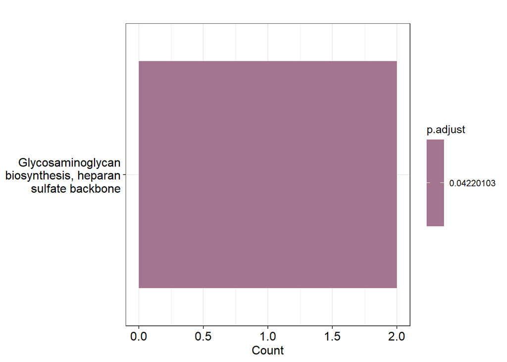

```r
barplot(enrichMKEGG.LassoOv)
```

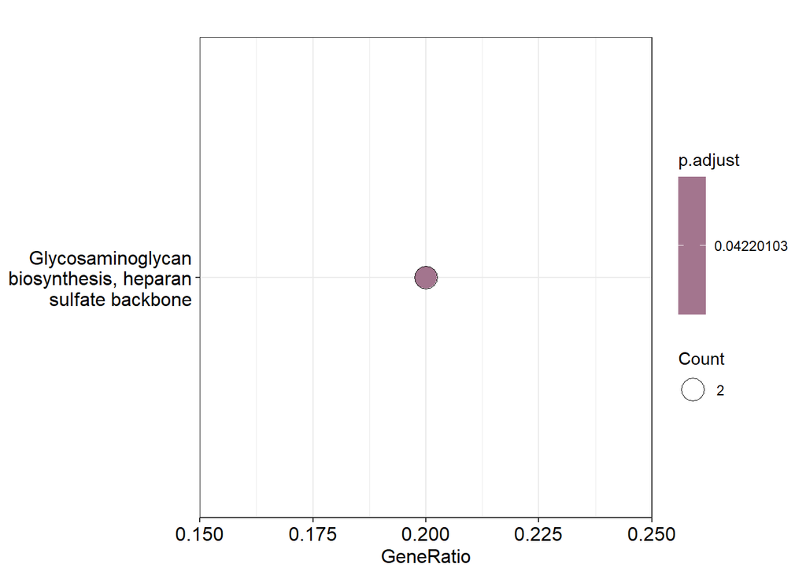

```r
clusterProfiler::dotplot(enrichMKEGG.LassoOv, orderBy="GeneRatio")
```

```r
MKEGG_genesLassoOv <- as.data.frame(enrichMKEGG.LassoOv)

# Añadimos una columna con los Symbol:
for (i in 1:nrow(MKEGG_genesLassoOv)) {
  GenesMKeggLassoOv <- unlist(strsplit(MKEGG_genesLassoOv[i, "geneID"], "/"))
  GenesMKeggLassoOv_Symbol <- as.list(LassoOv.bitr[LassoOv.bitr$ENTREZID %in% GenesMKeggLasso, "SYMBOL"])
  MKEGG_genesLassoOv[i, "geneID"] <- paste(GenesMKeggLassoOv_Symbol, collapse = " ")
}

MKEGG_genesLassoOv <- MKEGG_genesLassoOv[order(MKEGG_genesLassoOv$qvalue, decreasing = FALSE), ]
MKEGG_genesLassoOv$Ontology <- "MKEGG"
MKEGG_genesLassoOv$Model <- "Lasso OV"


kbl(MKEGG_genesLassoOv, format = "html", row.names = FALSE)  %>%
kable_paper() %>%
  scroll_box(width = "100%", height = "150px")
```

| ID | Description | GeneRatio | BgRatio | pvalue | p.adjust | qvalue | geneID | Count | Ontology | Model |
| --- | --- | --- | --- | --- | --- | --- | --- | --- | --- | --- |
| M00059 | Glycosaminoglycan biosynthesis, heparan sulfate backbone | 2/10 | 10/855 | 0.0052751 | 0.042201 | 0.0388694 | PFKP | 2 | MKEGG | Lasso OV |

## 2.4 Enriquecimiento mediante la base de datos Disease Ontology (DO)

Para el análisis DOSE se obtienen 2 términos cercanos a ser significativos. No obstante, no presentan una relación con la enfermedad de Parkinson por lo que serán filtrados en el proceso posterior.

```r
eDOLassoOv <- enrichDO(gene          = LassoOv.EntrezID,
              ont           = "DO",
              pvalueCutoff  = 0.1,
              pAdjustMethod = "BH",
              minGSSize     = 1,
              maxGSSize     = 500,
              qvalueCutoff  = 0.1,
              readable      = FALSE)
```

```r
kbl(eDOLassoOv, format = "html", row.names = FALSE)  %>%
kable_paper() %>%
  scroll_box(width = "100%", height = "200px")
```

| ID | Description | GeneRatio | BgRatio | pvalue | p.adjust | qvalue | geneID | Count |
| --- | --- | --- | --- | --- | --- | --- | --- | --- |
| DOID:0110155 | Charcot-Marie-Tooth disease type 2A2A | 2/138 | 2/10312 | 0.0001778 | 0.0569881 | 0.0515649 | 9927/55669 | 2 |
| DOID:0111557 | Charcot-Marie-Tooth disease type 2A2B | 2/138 | 2/10312 | 0.0001778 | 0.0569881 | 0.0515649 | 9927/55669 | 2 |

## 2.5 Enriquecimiento mediante GSEA

De igual manera que en Lasso, el análisis GSEA no presenta resultados significativos.

```r
predictoresLassoOvGSEA <- predictoresLasso_Over
predictoresLassoOvGSEA <- arrange(predictoresLassoOvGSEA, desc(coeficientes))

vectorLassoOvGSEA <- predictoresLassoOvGSEA$coeficientes; names(vectorLassoOvGSEA) <- predictoresLassoOvGSEA$Predictores
names(vectorLassoOvGSEA) <- sub("^circ", "", names(vectorLassoOvGSEA))

gsea_resultsLassoOv <- GSEA(
  geneList = vectorLassoOvGSEA, # Ordered ranked gene list
  minGSSize = 1, # Minimum gene set size
  pvalueCutoff = 0.5,
  eps = 0, # Boundary for calculating the p value
  seed = FALSE, # Set seed to make results reproducible
  pAdjustMethod = "BH", # Benjamini-Hochberg correction
  TERM2GENE = dplyr::select(
    hs_sets,
    gs_name,
    gene_symbol
  )
)
```

```r
GSEA_LassoOvTotal <- as.data.frame(gsea_resultsLassoOv)
# GSEA_LassoTotal_filtrado <- GSEA_LassoTotal[GSEA_LassoTotal$qvalue < 0.5, ]

GSEA_LassoOv <- GSEA_LassoOvTotal[order(GSEA_LassoOvTotal$qvalue, decreasing = FALSE), ]

GSEA_LassoOv$core_enrichment <- gsub("/", " ", GSEA_LassoOv$core_enrichment, fixed = TRUE)

GSEA_LassoOv$Model <- "LASSO OV"

kbl(GSEA_LassoOv, format = "html", row.names = FALSE)  %>%
kable_paper() %>%
  scroll_box(width = "100%", height = "300px")
```

| ID | Description | setSize | enrichmentScore | NES | pvalue | p.adjust | qvalue | rank | leading_edge | core_enrichment | Model |
| --- | --- | --- | --- | --- | --- | --- | --- | --- | --- | --- | --- |
| BONOME_OVARIAN_CANCER_SURVIVAL_OPTIMAL_DEBULKING | BONOME_OVARIAN_CANCER_SURVIVAL_OPTIMAL_DEBULKING | 4 | -0.9718719 | -1.784077 | 1.74e-05 | 0.1524913 | 0.1524913 | 10 | tags=75%, list=4%, signal=73% | SON NSD1 RALGAPA1 | LASSO OV |
| GCM_PTK2 | GCM_PTK2 | 4 | -0.9717045 | -1.783769 | 1.77e-05 | 0.1524913 | 0.1524913 | 6 | tags=75%, list=2%, signal=74% | RTN4 ANKRD17 RALGAPA1 | LASSO OV |
| HP_RENAL_AGENESIS | HP_RENAL_AGENESIS | 4 | -0.9602189 | -1.762685 | 5.20e-05 | 0.2988879 | 0.2988879 | 10 | tags=75%, list=4%, signal=73% | SON NSD1 ANKRD17 | LASSO OV |
| GSE2706_UNSTIM_VS_2H_LPS_AND_R848_DC_UP | GSE2706_UNSTIM_VS_2H_LPS_AND_R848_DC_UP | 4 | -0.9558567 | -1.754677 | 7.38e-05 | 0.3181838 | 0.3181838 | 9 | tags=75%, list=4%, signal=73% | NSD1 SLC24A4 ANKRD17 | LASSO OV |

# 3 Enriquecimiento circRNA procedentes de Random Forest

El último conjunto sometido a análisis de enriquecimiento será el compuesto por los 218 circRNA seleccionados como el top en importancia del modelo Random Forest.

Para este modelo se van a utilizar umbrales de significación más bajos ya que de manera general se obtiene un número mayor de resultados.

```r
predictoresRF <- readRDS("../1. ML/predictoresRF_sort")

# Seleccionamos los predictores más importantes (el cuantil 0.90 más importante)
ImpRF <- predictoresRF[predictoresRF$Overall > quantile(predictoresRF$Overall, 0.90), ]
predictoresRF10 <- rownames(predictoresRF[1:length(ImpRF), , drop = FALSE])
predictoresRF_Symbol <- sub("^circ", "", predictoresRF10)
```

## 3.1 Enriquecimiento mediante la base de datos *Gene Ontology*

En cuanto a los resultados de *Gene Ontology* se obtiene un total de 57 términos todos significativos.

```r
eGORF <- enrichGO(gene = predictoresRF_Symbol,
                OrgDb = "org.Hs.eg.db",
                qvalueCutoff = 0.05,
                pvalueCutoff = 0.05,
                keyType = "SYMBOL",
                ont = "all"
                )
head(summary(as.data.frame(eGORF)))
```

```
##    ONTOLOGY              ID            Description         GeneRatio
##  Length:57          Length:57          Length:57          Length:57
##  Class :character   Class :character   Class :character   Class :character
##  Mode  :character   Mode  :character   Mode  :character   Mode  :character
##
##
##
##    BgRatio              pvalue             p.adjust             qvalue
##  Length:57          Min.   :7.046e-07   Min.   :0.0006114   Min.   :0.0005525
##  Class :character   1st Qu.:2.175e-05   1st Qu.:0.0039435   1st Qu.:0.0035635
##  Mode  :character   Median :1.729e-04   Median :0.0195690   Median :0.0176833
##                     Mean   :2.495e-04   Mean   :0.0194565   Mean   :0.0175824
##                     3rd Qu.:3.843e-04   3rd Qu.:0.0296458   3rd Qu.:0.0267891
##                     Max.   :8.655e-04   Max.   :0.0470852   Max.   :0.0425480
##     geneID              Count
##  Length:57          Min.   : 3.000
##  Class :character   1st Qu.: 6.000
##  Mode  :character   Median : 9.000
##                     Mean   : 9.105
##                     3rd Qu.:12.000
##                     Max.   :19.000
```

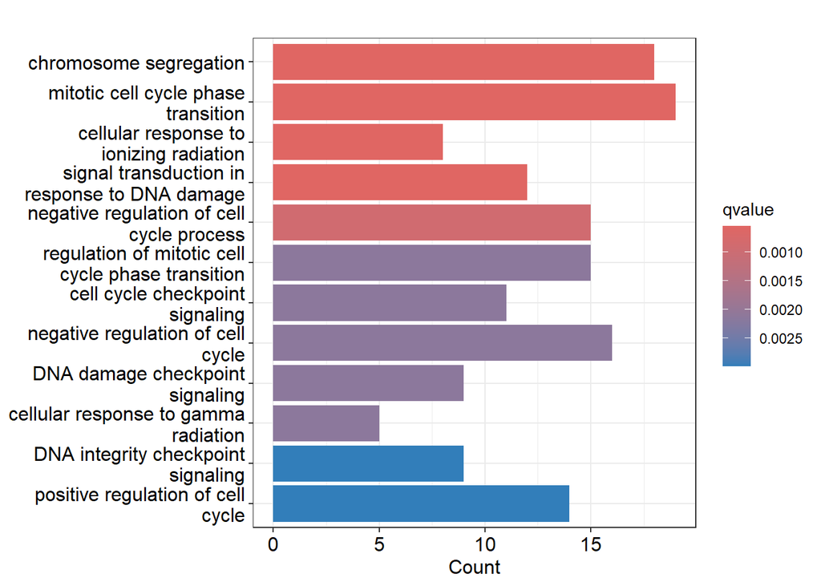

```r
barplot(eGORF, showCategory = 12, color="qvalue")
```

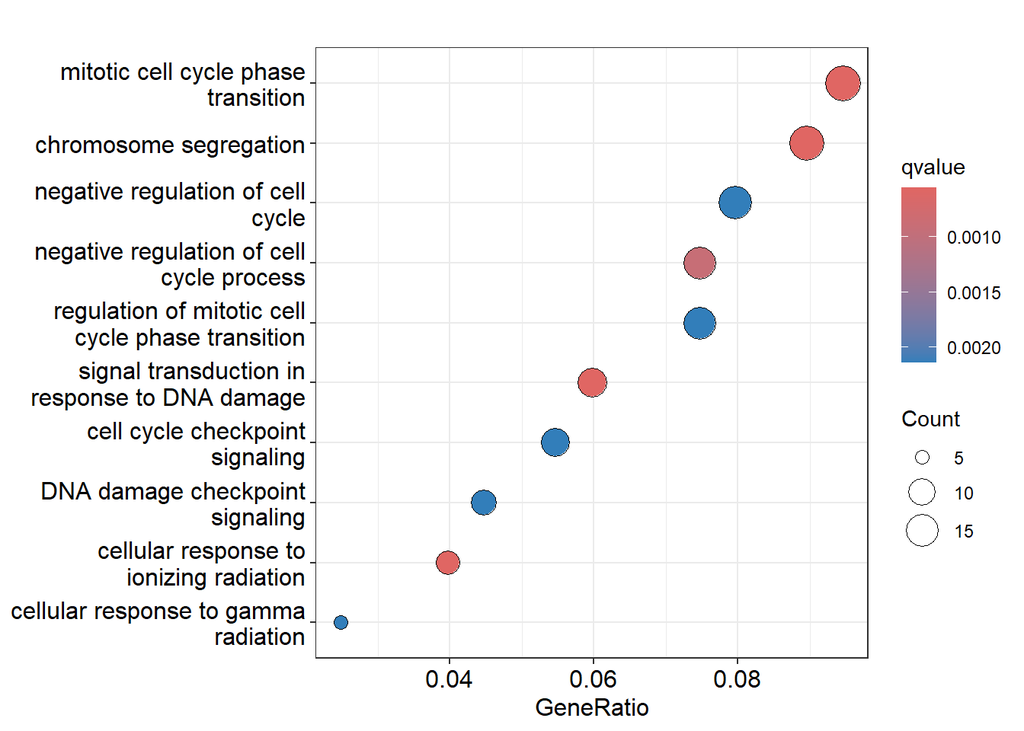

```r
clusterProfiler::dotplot(eGORF, orderBy="GeneRatio", color = "qvalue",showCategory = 10)
```

```r
enriGO_genesRF_Total <- as.data.frame(eGORF)
enriGO_genesRF <- as.data.frame(eGORF)

GO_genesRF <- enriGO_genesRF[order(enriGO_genesRF$qvalue, decreasing = FALSE), ]
GO_genesRF$geneID <- gsub("/", " ", GO_genesRF$geneID, fixed = TRUE)
GO_genesRF$Model <- "RF"

kbl(GO_genesRF, format = "html", row.names = FALSE)  %>%
kable_paper() %>%
  scroll_box(width = "100%", height = "500px")
```

| ONTOLOGY | ID | Description | GeneRatio | BgRatio | pvalue | p.adjust | qvalue | geneID | Count | Model |
| --- | --- | --- | --- | --- | --- | --- | --- | --- | --- | --- |
| BP | GO:0007059 | chromosome segregation | 18/201 | 424/18870 | 0.0000007 | 0.0006114 | 0.0005525 | WAPL ECT2 KIF14 ASPM TUBGCP5 CHEK2 TLK2 LATS1 STAG1 BRCA1 PUM2 TPX2 CDK5RAP2 MMS19 STIL UBE2I SETDB2 BUB1 | 18 | RF |
| BP | GO:0044772 | mitotic cell cycle phase transition | 19/201 | 470/18870 | 0.0000007 | 0.0006114 | 0.0005525 | KIF14 CHEK2 RBL1 LATS1 KMT2E KDM8 NPAT UIMC1 BRCA1 BARD1 RNASEH2B CDK5RAP2 ANKRD17 DTL WAC PPP2R2D STIL MDM2 BUB1 | 19 | RF |
| BP | GO:0071479 | cellular response to ionizing radiation | 8/201 | 70/18870 | 0.0000008 | 0.0006114 | 0.0005525 | ECT2 CHEK2 TLK2 KDM1A BRCA1 BARD1 ZMPSTE24 MDM2 | 8 | RF |
| BP | GO:0042770 | signal transduction in response to DNA damage | 12/201 | 189/18870 | 0.0000009 | 0.0006114 | 0.0005525 | ATRX CHEK2 UIMC1 KDM1A BRCA1 BARD1 PTPN11 RNASEH2B ZMPSTE24 DTL WAC MDM2 | 12 | RF |
| BP | GO:0010948 | negative regulation of cell cycle process | 15/201 | 320/18870 | 0.0000018 | 0.0010013 | 0.0009048 | WAPL ATRX CHEK2 RBL1 UIMC1 BRCA1 BARD1 PTPN11 RNASEH2B CDK5RAP2 DTL WAC TERF2 MDM2 BUB1 | 15 | RF |
| BP | GO:1901990 | regulation of mitotic cell cycle phase transition | 15/201 | 355/18870 | 0.0000065 | 0.0023675 | 0.0021393 | KIF14 CHEK2 RBL1 KMT2E UIMC1 BRCA1 BARD1 RNASEH2B CDK5RAP2 ANKRD17 DTL WAC STIL MDM2 BUB1 | 15 | RF |
| BP | GO:0000075 | cell cycle checkpoint signaling | 11/201 | 192/18870 | 0.0000070 | 0.0023675 | 0.0021393 | CHEK2 UIMC1 BRCA1 BARD1 PTPN11 RNASEH2B CDK5RAP2 DTL WAC MDM2 BUB1 | 11 | RF |
| BP | GO:0045786 | negative regulation of cell cycle | 16/201 | 407/18870 | 0.0000079 | 0.0023675 | 0.0021393 | WAPL ATRX CHEK2 RBL1 LATS1 UIMC1 BRCA1 BARD1 PTPN11 RNASEH2B CDK5RAP2 DTL WAC TERF2 MDM2 BUB1 | 16 | RF |
| BP | GO:0000077 | DNA damage checkpoint signaling | 9/201 | 126/18870 | 0.0000083 | 0.0023675 | 0.0021393 | CHEK2 UIMC1 BRCA1 BARD1 PTPN11 RNASEH2B DTL WAC MDM2 | 9 | RF |
| BP | GO:0071480 | cellular response to gamma radiation | 5/201 | 27/18870 | 0.0000087 | 0.0023675 | 0.0021393 | CHEK2 TLK2 KDM1A ZMPSTE24 MDM2 | 5 | RF |
| BP | GO:0031570 | DNA integrity checkpoint signaling | 9/201 | 135/18870 | 0.0000145 | 0.0033080 | 0.0029893 | CHEK2 UIMC1 BRCA1 BARD1 PTPN11 RNASEH2B DTL WAC MDM2 | 9 | RF |
| BP | GO:0045787 | positive regulation of cell cycle | 14/201 | 334/18870 | 0.0000146 | 0.0033080 | 0.0029893 | ECT2 KIF14 ATRX KMT2E CEP295 PTPN11 CCPG1 USP22 ANKRD17 DTL STIL MDM2 SLF2 BUB1 | 14 | RF |
| BP | GO:0010212 | response to ionizing radiation | 9/201 | 138/18870 | 0.0000173 | 0.0036216 | 0.0032726 | ECT2 CHEK2 TLK2 UIMC1 KDM1A BRCA1 BARD1 ZMPSTE24 MDM2 | 9 | RF |
| BP | GO:0000086 | G2/M transition of mitotic cell cycle | 9/201 | 140/18870 | 0.0000194 | 0.0037732 | 0.0034096 | KIF14 CHEK2 LATS1 KDM8 UIMC1 BRCA1 BARD1 RNASEH2B DTL | 9 | RF |
| BP | GO:0007093 | mitotic cell cycle checkpoint signaling | 9/201 | 142/18870 | 0.0000217 | 0.0039436 | 0.0035635 | CHEK2 UIMC1 BRCA1 BARD1 CDK5RAP2 DTL WAC MDM2 BUB1 | 9 | RF |
| BP | GO:0007063 | regulation of sister chromatid cohesion | 4/201 | 17/18870 | 0.0000267 | 0.0045347 | 0.0040977 | WAPL ATRX SLF2 BUB1 | 4 | RF |
| BP | GO:1901987 | regulation of cell cycle phase transition | 16/201 | 456/18870 | 0.0000320 | 0.0051187 | 0.0046254 | KIF14 CHEK2 RBL1 KMT2E UIMC1 BRCA1 BARD1 PTPN11 RNASEH2B CDK5RAP2 ANKRD17 DTL WAC STIL MDM2 BUB1 | 16 | RF |
| BP | GO:0044839 | cell cycle G2/M phase transition | 9/201 | 155/18870 | 0.0000434 | 0.0062772 | 0.0056723 | KIF14 CHEK2 LATS1 KDM8 UIMC1 BRCA1 BARD1 RNASEH2B DTL | 9 | RF |
| BP | GO:1901988 | negative regulation of cell cycle phase transition | 12/201 | 277/18870 | 0.0000438 | 0.0062772 | 0.0056723 | CHEK2 RBL1 UIMC1 BRCA1 BARD1 PTPN11 RNASEH2B CDK5RAP2 DTL WAC MDM2 BUB1 | 12 | RF |
| BP | GO:1901991 | negative regulation of mitotic cell cycle phase transition | 10/201 | 196/18870 | 0.0000494 | 0.0067120 | 0.0060652 | CHEK2 RBL1 UIMC1 BRCA1 BARD1 CDK5RAP2 DTL WAC MDM2 BUB1 | 10 | RF |
| BP | GO:0007099 | centriole replication | 5/201 | 43/18870 | 0.0000904 | 0.0116709 | 0.0105462 | CEP295 BRCA1 RTTN CDK5RAP2 STIL | 5 | RF |
| BP | GO:0046599 | regulation of centriole replication | 4/201 | 23/18870 | 0.0000944 | 0.0116709 | 0.0105462 | CEP295 BRCA1 CDK5RAP2 STIL | 4 | RF |
| MF | GO:0030374 | nuclear receptor coactivator activity | 6/201 | 55/18496 | 0.0000284 | 0.0124032 | 0.0107801 | PRKCB MED13 KDM1A NCOA1 CNOT6 USP22 | 6 | RF |
| BP | GO:0090068 | positive regulation of cell cycle process | 11/201 | 262/18870 | 0.0001206 | 0.0142667 | 0.0128919 | ECT2 KIF14 ATRX KMT2E CEP295 ANKRD17 DTL STIL MDM2 SLF2 BUB1 | 11 | RF |
| BP | GO:0140694 | non-membrane-bounded organelle assembly | 14/201 | 408/18870 | 0.0001272 | 0.0144139 | 0.0130249 | ATXN2 ASPM TUBGCP5 CHEK2 CEP295 STAG1 BRCA1 PUM2 CNOT6 RTTN TPX2 PAN3 CDK5RAP2 STIL | 14 | RF |
| BP | GO:0071478 | cellular response to radiation | 9/201 | 181/18870 | 0.0001432 | 0.0155824 | 0.0140808 | ECT2 CHEK2 TLK2 KDM1A BRCA1 BARD1 ZMPSTE24 RHBDD1 MDM2 | 9 | RF |
| BP | GO:0098534 | centriole assembly | 5/201 | 48/18870 | 0.0001540 | 0.0161098 | 0.0145574 | CEP295 BRCA1 RTTN CDK5RAP2 STIL | 5 | RF |
| BP | GO:0090398 | cellular senescence | 7/201 | 110/18870 | 0.0001767 | 0.0177966 | 0.0160817 | RSL1D1 SPI1 OPA1 RBL1 MORC3 ZMPSTE24 TERF2 | 7 | RF |
| BP | GO:0010332 | response to gamma radiation | 5/201 | 51/18870 | 0.0002059 | 0.0195690 | 0.0176833 | CHEK2 TLK2 KDM1A ZMPSTE24 MDM2 | 5 | RF |
| BP | GO:0009314 | response to radiation | 14/201 | 428/18870 | 0.0002086 | 0.0195690 | 0.0176833 | ECT2 CHEK2 BRAF TLK2 UIMC1 KDM1A BRCA1 BARD1 MAP4K3 ZMPSTE24 DTL NF1 RHBDD1 MDM2 | 14 | RF |
| BP | GO:0044773 | mitotic DNA damage checkpoint signaling | 6/201 | 83/18870 | 0.0002589 | 0.0234724 | 0.0212106 | CHEK2 UIMC1 BRCA1 DTL WAC MDM2 | 6 | RF |
| BP | GO:2000772 | regulation of cellular senescence | 5/201 | 54/18870 | 0.0002701 | 0.0236983 | 0.0214147 | RSL1D1 RBL1 MORC3 ZMPSTE24 TERF2 | 5 | RF |
| BP | GO:0007064 | mitotic sister chromatid cohesion | 4/201 | 31/18870 | 0.0003138 | 0.0248995 | 0.0225001 | ATRX STAG1 SLF2 BUB1 | 4 | RF |
| BP | GO:0034086 | maintenance of sister chromatid cohesion | 3/201 | 13/18870 | 0.0003147 | 0.0248995 | 0.0225001 | ATRX SLF2 BUB1 | 3 | RF |
| BP | GO:0034088 | maintenance of mitotic sister chromatid cohesion | 3/201 | 13/18870 | 0.0003147 | 0.0248995 | 0.0225001 | ATRX SLF2 BUB1 | 3 | RF |
| BP | GO:0033044 | regulation of chromosome organization | 10/201 | 247/18870 | 0.0003280 | 0.0248995 | 0.0225001 | WAPL ATRX XRN1 USP7 CDK5RAP2 MAPK1 TERF2 SETDB2 SLF2 BUB1 | 10 | RF |
| BP | GO:0044774 | mitotic DNA integrity checkpoint signaling | 6/201 | 87/18870 | 0.0003344 | 0.0248995 | 0.0225001 | CHEK2 UIMC1 BRCA1 DTL WAC MDM2 | 6 | RF |
| BP | GO:0045930 | negative regulation of mitotic cell cycle | 10/201 | 248/18870 | 0.0003387 | 0.0248995 | 0.0225001 | CHEK2 RBL1 UIMC1 BRCA1 BARD1 CDK5RAP2 DTL WAC MDM2 BUB1 | 10 | RF |
| BP | GO:0000082 | G1/S transition of mitotic cell cycle | 10/201 | 252/18870 | 0.0003843 | 0.0275098 | 0.0248589 | KIF14 CHEK2 RBL1 LATS1 KMT2E NPAT ANKRD17 WAC STIL MDM2 | 10 | RF |
| BP | GO:0007062 | sister chromatid cohesion | 5/201 | 59/18870 | 0.0004096 | 0.0285650 | 0.0258124 | WAPL ATRX STAG1 SLF2 BUB1 | 5 | RF |
| CC | GO:0072686 | mitotic spindle | 9/207 | 184/19886 | 0.0001371 | 0.0290997 | 0.0265910 | WAPL ECT2 ASPM CEP295 STAG1 EPB41 TPX2 CDK5RAP2 MAPK1 | 9 | RF |
| CC | GO:0005819 | spindle | 14/207 | 431/19886 | 0.0001785 | 0.0290997 | 0.0265910 | CEP350 WAPL ECT2 KIF14 ASPM TUBGCP5 LATS1 CEP295 STAG1 EPB41 TPX2 CDK5RAP2 MAPK1 MMS19 | 14 | RF |
| BP | GO:0030900 | forebrain development | 13/201 | 407/18870 | 0.0004400 | 0.0296458 | 0.0267891 | KIF14 ATRX ASPM WDR37 ZEB1 PCM1 KDM1A CRKL SCYL2 NCOA1 HERC1 NF1 STIL | 13 | RF |
| BP | GO:0045931 | positive regulation of mitotic cell cycle | 7/201 | 128/18870 | 0.0004469 | 0.0296458 | 0.0267891 | KMT2E PTPN11 USP22 ANKRD17 DTL STIL MDM2 | 7 | RF |
| BP | GO:1903432 | regulation of TORC1 signaling | 6/201 | 93/18870 | 0.0004788 | 0.0310103 | 0.0280221 | ITFG2 USP32 RHEB USP7 CLEC16A WAC | 6 | RF |
| BP | GO:2001251 | negative regulation of chromosome organization | 6/201 | 94/18870 | 0.0005070 | 0.0316000 | 0.0285550 | WAPL ATRX XRN1 CDK5RAP2 TERF2 BUB1 | 6 | RF |
| BP | GO:0006282 | regulation of DNA repair | 9/201 | 215/18870 | 0.0005112 | 0.0316000 | 0.0285550 | UIMC1 KDM1A BRCA1 BARD1 USP22 SUPT20H MMS19 TERF2 SLF2 | 9 | RF |
| CC | GO:0099243 | extrinsic component of synaptic membrane | 3/207 | 14/19886 | 0.0003718 | 0.0354697 | 0.0324117 | PICALM CRKL AKAP9 | 3 | RF |
| CC | GO:0031965 | nuclear membrane | 11/207 | 311/19886 | 0.0004352 | 0.0354697 | 0.0324117 | PCM1 TEX2 CEPT1 NUP107 GLE1 NEMP1 PUM2 NUP50 ZMPSTE24 ANKRD17 DTL | 11 | RF |
| MF | GO:0016887 | ATP hydrolysis activity | 14/201 | 412/18496 | 0.0001729 | 0.0376855 | 0.0327542 | KIF14 ATRX CHD9 PEX6 ATAD2B RHOBTB3 LONP2 RAD54L2 DDX50 ATAD2 ABCG2 MORC3 DHX34 PMS1 | 14 | RF |
| BP | GO:0038202 | TORC1 signaling | 6/201 | 99/18870 | 0.0006678 | 0.0403651 | 0.0364754 | ITFG2 USP32 RHEB USP7 CLEC16A WAC | 6 | RF |
| CC | GO:0005635 | nuclear envelope | 14/207 | 494/19886 | 0.0006995 | 0.0456087 | 0.0416767 | PCM1 TEX2 CEPT1 MGST2 FANCL NUP107 GLE1 NEMP1 PUM2 NUP50 ZMPSTE24 ANKRD17 DTL UBE2I | 14 | RF |
| BP | GO:2000045 | regulation of G1/S transition of mitotic cell cycle | 8/201 | 183/18870 | 0.0007868 | 0.0465241 | 0.0420409 | KIF14 CHEK2 RBL1 KMT2E ANKRD17 WAC STIL MDM2 | 8 | RF |
| BP | GO:0044843 | cell cycle G1/S phase transition | 10/201 | 279/18870 | 0.0008458 | 0.0470852 | 0.0425480 | KIF14 CHEK2 RBL1 LATS1 KMT2E NPAT ANKRD17 WAC STIL MDM2 | 10 | RF |
| BP | GO:0010389 | regulation of G2/M transition of mitotic cell cycle | 6/201 | 104/18870 | 0.0008655 | 0.0470852 | 0.0425480 | KIF14 UIMC1 BRCA1 BARD1 RNASEH2B DTL | 6 | RF |
| BP | GO:0021549 | cerebellum development | 6/201 | 104/18870 | 0.0008655 | 0.0470852 | 0.0425480 | KIF14 AARS1 CRKL NCOA1 HERC1 PTPN11 | 6 | RF |
| BP | GO:0032204 | regulation of telomere maintenance | 6/201 | 104/18870 | 0.0008655 | 0.0470852 | 0.0425480 | ATRX XRN1 USP7 MAPK1 TERF2 SLF2 | 6 | RF |

## 3.2 Enriquecimiento mediante la base de datos KEGG

El resultado al enriquecer sobre términos KEGG supone un total de 26 términos, de los cuales 9 son significativos.

```r
# Convertir los identificadores
RF.bitr <- bitr(predictoresRF_Symbol, fromType = "SYMBOL",
                toType = c("ENTREZID"),
                OrgDb = "org.Hs.eg.db")
RF.EntrezID <- RF.bitr$ENTREZID
```

```r
enrichKEGG.RF <- enrichKEGG(gene = RF.EntrezID,
                 organism     = "hsa",
                 pvalueCutoff = 0.5,
                 keyType = "ncbi-geneid")
summary(as.data.frame(enrichKEGG.RF))
```

```
##    category         subcategory             ID            Description
##  Length:26          Length:26          Length:26          Length:26
##  Class :character   Class :character   Class :character   Class :character
##  Mode  :character   Mode  :character   Mode  :character   Mode  :character
##
##
##
##   GeneRatio           BgRatio              pvalue             p.adjust
##  Length:26          Length:26          Min.   :0.0002719   Min.   :0.04971
##  Class :character   Class :character   1st Qu.:0.0017888   1st Qu.:0.05105
##  Mode  :character   Mode  :character   Median :0.0078297   Median :0.12437
##                                        Mean   :0.0105811   Mean   :0.12870
##                                        3rd Qu.:0.0194754   3rd Qu.:0.20981
##                                        Max.   :0.0263756   Max.   :0.22419
##      qvalue           geneID              Count
##  Min.   :0.04356   Length:26          Min.   :3.000
##  1st Qu.:0.04474   Class :character   1st Qu.:4.000
##  Median :0.10900   Mode  :character   Median :5.000
##  Mean   :0.11280                      Mean   :5.077
##  3rd Qu.:0.18388                      3rd Qu.:5.000
##  Max.   :0.19648                      Max.   :8.000
```

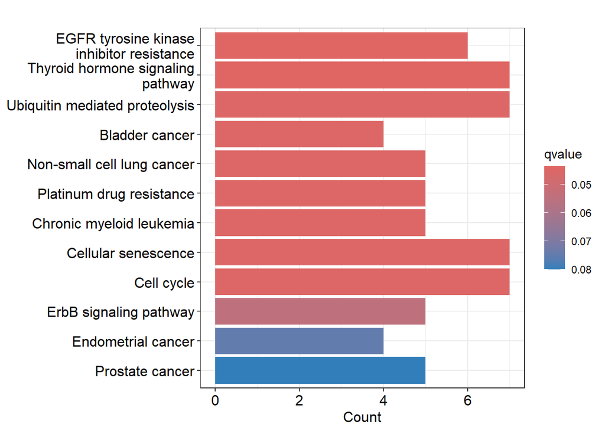

```r
barplot(enrichKEGG.RF, showCategory = 12, color="qvalue")
```

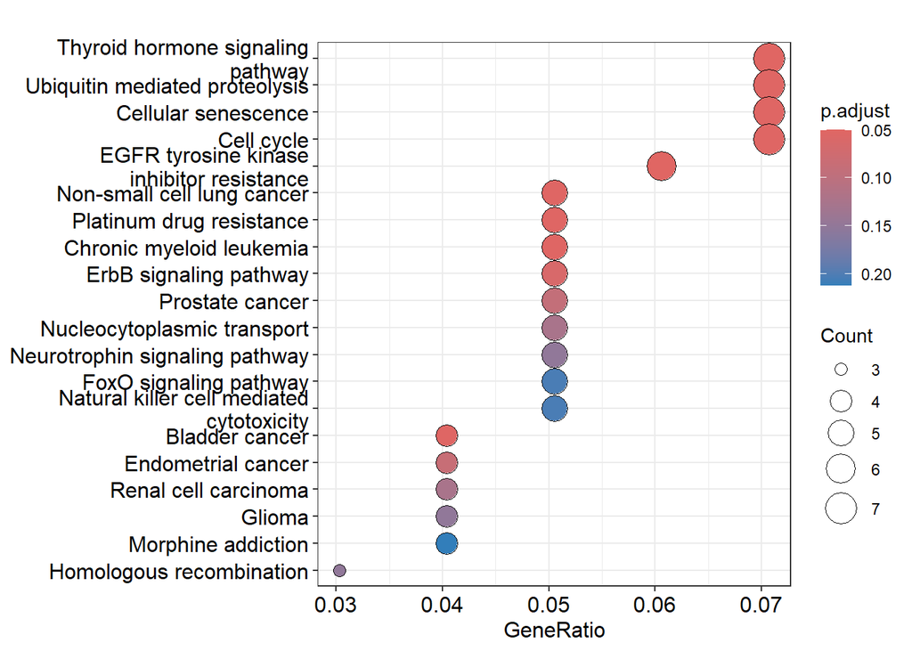

```r
clusterProfiler::dotplot(enrichKEGG.RF, orderBy="GeneRatio", showCategory = 20)
```

```r
Kegg_genesRF <- as.data.frame(enrichKEGG.RF)

# Añadimos una columna con los Symbol:
for (i in 1:nrow(Kegg_genesRF)) {
  GenesKeggRF <- unlist(strsplit(Kegg_genesRF[i, "geneID"], "/"))
  GenesKeggRF_Symbol <- as.list(RF.bitr[RF.bitr$ENTREZID %in% GenesKeggRF, "SYMBOL"])
  Kegg_genesRF[i, "geneID"] <- paste(GenesKeggRF_Symbol, collapse = " ")
}

Kegg_genesRF <- Kegg_genesRF[order(Kegg_genesRF$qvalue, decreasing = FALSE), ]
Kegg_genesRF$Ontology <- "KEGG"
Kegg_genesRF$Model <- "RF"


kbl(Kegg_genesRF, format = "html", row.names = FALSE)  %>%
kable_paper() %>%
  scroll_box(width = "100%", height = "500px")
```

| category | subcategory | ID | Description | GeneRatio | BgRatio | pvalue | p.adjust | qvalue | geneID | Count | Ontology | Model |
| --- | --- | --- | --- | --- | --- | --- | --- | --- | --- | --- | --- | --- |
| Human Diseases | Drug resistance: antineoplastic | hsa01521 | EGFR tyrosine kinase inhibitor resistance | 6/99 | 79/8659 | 0.0002719 | 0.0497072 | 0.0435633 | PRKCB BRAF FOXO3 ERBB2 MAPK1 NF1 | 6 | KEGG | RF |
| Organismal Systems | Endocrine system | hsa04919 | Thyroid hormone signaling pathway | 7/99 | 121/8659 | 0.0004498 | 0.0497072 | 0.0435633 | PRKCB MED13 NCOA1 SLC16A10 RHEB MAPK1 MDM2 | 7 | KEGG | RF |
| Genetic Information Processing | Folding, sorting and degradation | hsa04120 | Ubiquitin mediated proteolysis | 7/99 | 142/8659 | 0.0011656 | 0.0510539 | 0.0447436 | UBE2K FANCL BRCA1 HERC1 UBE3C UBE2I MDM2 | 7 | KEGG | RF |
| Human Diseases | Cancer: specific types | hsa05219 | Bladder cancer | 4/99 | 41/8659 | 0.0011771 | 0.0510539 | 0.0447436 | BRAF ERBB2 MAPK1 MDM2 | 4 | KEGG | RF |
| Human Diseases | Cancer: specific types | hsa05223 | Non-small cell lung cancer | 5/99 | 72/8659 | 0.0013478 | 0.0510539 | 0.0447436 | PRKCB BRAF FOXO3 ERBB2 MAPK1 | 5 | KEGG | RF |
| Human Diseases | Drug resistance: antineoplastic | hsa01524 | Platinum drug resistance | 5/99 | 73/8659 | 0.0014339 | 0.0510539 | 0.0447436 | MGST2 BRCA1 ERBB2 MAPK1 MDM2 | 5 | KEGG | RF |
| Human Diseases | Cancer: specific types | hsa05220 | Chronic myeloid leukemia | 5/99 | 76/8659 | 0.0017168 | 0.0510539 | 0.0447436 | BRAF CRKL PTPN11 MAPK1 MDM2 | 5 | KEGG | RF |
| Cellular Processes | Cell growth and death | hsa04218 | Cellular senescence | 7/99 | 156/8659 | 0.0020049 | 0.0510539 | 0.0447436 | CHEK2 RBL1 LIN54 FOXO3 RHEB MAPK1 MDM2 | 7 | KEGG | RF |
| Cellular Processes | Cell growth and death | hsa04110 | Cell cycle | 7/99 | 157/8659 | 0.0020791 | 0.0510539 | 0.0447436 | WAPL ATRX CHEK2 RBL1 STAG1 MDM2 BUB1 | 7 | KEGG | RF |
| Environmental Information Processing | Signal transduction | hsa04012 | ErbB signaling pathway | 5/99 | 85/8659 | 0.0028119 | 0.0621427 | 0.0544618 | PRKCB BRAF CRKL ERBB2 MAPK1 | 5 | KEGG | RF |
| Human Diseases | Cancer: specific types | hsa05213 | Endometrial cancer | 4/99 | 58/8659 | 0.0042533 | 0.0854519 | 0.0748899 | BRAF FOXO3 ERBB2 MAPK1 | 4 | KEGG | RF |
| Human Diseases | Cancer: specific types | hsa05215 | Prostate cancer | 5/99 | 97/8659 | 0.0049623 | 0.0913883 | 0.0800926 | BRAF ZEB1 ERBB2 MAPK1 MDM2 | 5 | KEGG | RF |
| Genetic Information Processing | Translation | hsa03013 | Nucleocytoplasmic transport | 5/99 | 108/8659 | 0.0077806 | 0.1243716 | 0.1089992 | THOC2 NUP107 GLE1 NUP50 UBE2I | 5 | KEGG | RF |
| Human Diseases | Cancer: specific types | hsa05211 | Renal cell carcinoma | 4/99 | 69/8659 | 0.0078787 | 0.1243716 | 0.1089992 | BRAF CRKL PTPN11 MAPK1 | 4 | KEGG | RF |
| Human Diseases | Cancer: specific types | hsa05214 | Glioma | 4/99 | 75/8659 | 0.0105176 | 0.1502716 | 0.1316979 | PRKCB BRAF MAPK1 MDM2 | 4 | KEGG | RF |
| Genetic Information Processing | Replication and repair | hsa03440 | Homologous recombination | 3/99 | 41/8659 | 0.0112856 | 0.1502716 | 0.1316979 | UIMC1 BRCA1 BARD1 | 3 | KEGG | RF |
| Organismal Systems | Nervous system | hsa04722 | Neurotrophin signaling pathway | 5/99 | 119/8659 | 0.0115594 | 0.1502716 | 0.1316979 | BRAF FOXO3 CRKL PTPN11 MAPK1 | 5 | KEGG | RF |
| Environmental Information Processing | Signal transduction | hsa04068 | FoxO signaling pathway | 5/99 | 131/8659 | 0.0169329 | 0.2029046 | 0.1778254 | BRAF FOXO3 USP7 MAPK1 MDM2 | 5 | KEGG | RF |
| Organismal Systems | Immune system | hsa04650 | Natural killer cell mediated cytotoxicity | 5/99 | 132/8659 | 0.0174443 | 0.2029046 | 0.1778254 | PRKCB BRAF PTPN11 MAPK1 NCR1 | 5 | KEGG | RF |
| Human Diseases | Substance dependence | hsa05032 | Morphine addiction | 4/99 | 91/8659 | 0.0201525 | 0.2121108 | 0.1858937 | PRKCB PDE3B PDE8A PDE7A | 4 | KEGG | RF |
| Organismal Systems | Endocrine system | hsa04910 | Insulin signaling pathway | 5/99 | 137/8659 | 0.0201553 | 0.2121108 | 0.1858937 | BRAF CRKL PDE3B RHEB MAPK1 | 5 | KEGG | RF |
| Organismal Systems | Immune system | hsa04666 | Fc gamma R-mediated phagocytosis | 4/99 | 97/8659 | 0.0248159 | 0.2241924 | 0.1964821 | PRKCB ASAP1 CRKL MAPK1 | 4 | KEGG | RF |
| Human Diseases | Cancer: overview | hsa05206 | MicroRNAs in cancer | 8/99 | 310/8659 | 0.0252325 | 0.2241924 | 0.1964821 | PRKCB ZEB1 CRKL BRCA1 ERBB2 MAPK1 UBE2I MDM2 | 8 | KEGG | RF |
| Human Diseases | Drug resistance: antineoplastic | hsa01522 | Endocrine resistance | 4/99 | 98/8659 | 0.0256514 | 0.2241924 | 0.1964821 | BRAF ERBB2 MAPK1 MDM2 | 4 | KEGG | RF |
| Human Diseases | Cancer: overview | hsa05231 | Choline metabolism in cancer | 4/99 | 98/8659 | 0.0256514 | 0.2241924 | 0.1964821 | PRKCB RHEB DGKE MAPK1 | 4 | KEGG | RF |
| Human Diseases | Cancer: specific types | hsa05224 | Breast cancer | 5/99 | 147/8659 | 0.0263756 | 0.2241924 | 0.1964821 | BRAF NCOA1 BRCA1 ERBB2 MAPK1 | 5 | KEGG | RF |

## 3.3 Enriquecimiento mediante la base de datos de módulos KEGG (MKEGG)

Los 3 resultados para el enriquecimiento con MKEGG en el conjunto Random forest presentan potencial debido a su relación con el metabolismo de lípidos (*Ceramide biosynthesis* y *Sphingosine biosynthesis*), el cual se relaciona con la degradación de la $\alpha$Syn por la vía lisosomal tal y como se presentó en el documento principal [jaime_niguez_baeza_tfm_parkinson](https://github.com/JaimeBioR/circRNA_Parkinson/blob/main/jaime_niguez_baeza_tfm_parkinson.pdf). Además vuelve a aparecer enriquecido el término *Glycosaminoglycan biosynthesis, heparan sulfate backbone* al igual que para los enriquecimientos anteriores. No obstante, aunque presentan $q-values$ relativamente bajos, no serán considerados en el estudio por superar el umbral de significación establecido.

```r
enrichMKEGG.RF <- enrichMKEGG(gene = RF.EntrezID,
                   organism = 'hsa',
                   pvalueCutoff = 1.0,
                   keyType = "ncbi-geneid")
```

[output not shown]

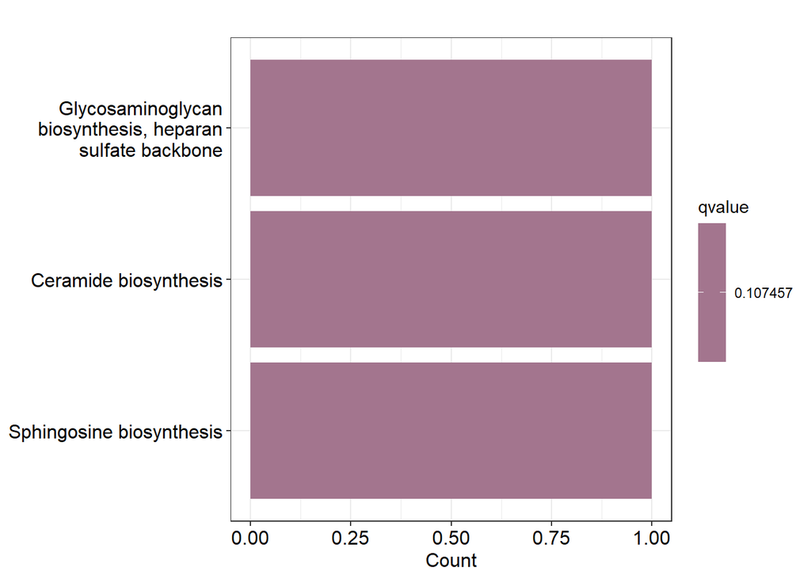

```r
barplot(enrichMKEGG.RF, color="qvalue")
```

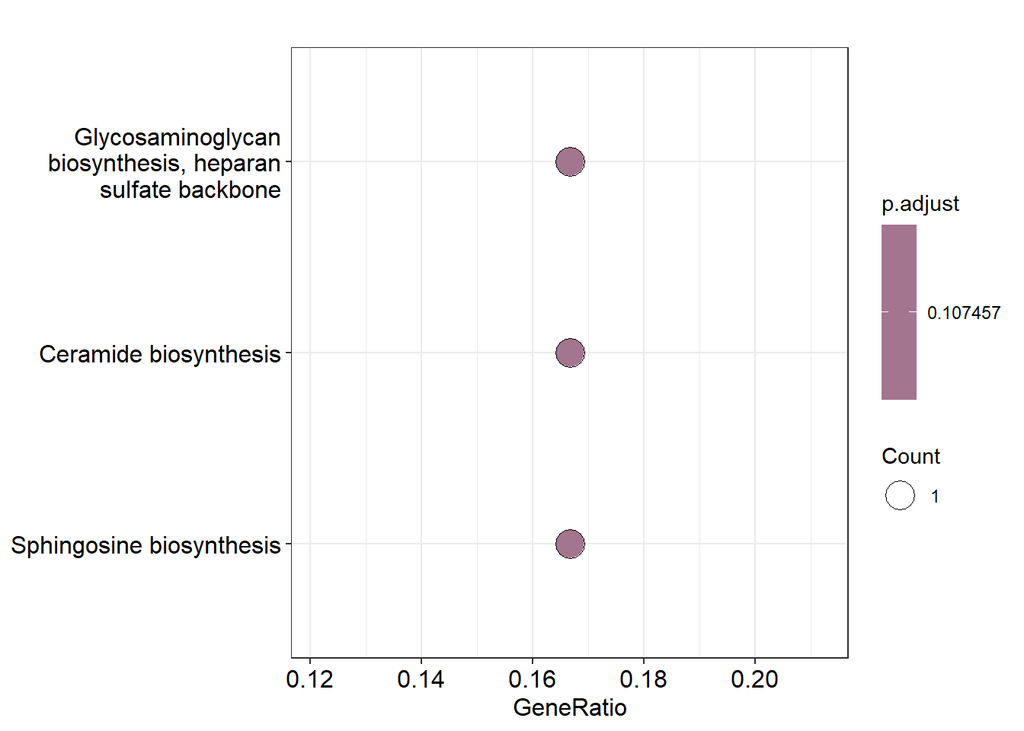

```r
clusterProfiler::dotplot(enrichMKEGG.RF, orderBy="GeneRatio")
```

```r
MKEGG_genesRF <- as.data.frame(enrichMKEGG.RF)

# Añadimos una columna con los Symbol:
for (i in 1:nrow(MKEGG_genesRF)) {
  GenesMKeggRF <- unlist(strsplit(MKEGG_genesRF[i, "geneID"], "/"))
  GenesMKeggRF_Symbol <- as.list(RF.bitr[RF.bitr$ENTREZID %in% GenesMKeggRF, "SYMBOL"])
  MKEGG_genesRF[i, "geneID"] <- paste(GenesMKeggRF_Symbol, collapse = " ")
}


MKegg_RF <- MKEGG_genesRF[order(MKEGG_genesRF$qvalue, decreasing = FALSE), ]
MKegg_RF$Ontology <- "MKEGG"
MKegg_RF$Model <- "RF"

kbl(MKegg_RF, format = "html", row.names = FALSE)  %>%
kable_paper() %>%
  scroll_box(width = "100%", height = "250px")
```

| ID | Description | GeneRatio | BgRatio | pvalue | p.adjust | qvalue | geneID | Count | Ontology | Model |
| --- | --- | --- | --- | --- | --- | --- | --- | --- | --- | --- |
| M00059 | Glycosaminoglycan biosynthesis, heparan sulfate backbone | 1/6 | 10/855 | 0.0683495 | 0.107457 | 0.107457 | EXTL3 | 1 | MKEGG | RF |
| M00094 | Ceramide biosynthesis | 1/6 | 12/855 | 0.0815409 | 0.107457 | 0.107457 | CERS6 | 1 | MKEGG | RF |
| M00099 | Sphingosine biosynthesis | 1/6 | 16/855 | 0.1074570 | 0.107457 | 0.107457 | CERS6 | 1 | MKEGG | RF |

## 3.4 Enriquecimiento mediante la base de datos Disease Ontology (DO)

```r
eDORF <- enrichDO(gene          = RF.EntrezID,
              ont           = "DO",
              pAdjustMethod = "BH",
              minGSSize     = 1,
              maxGSSize     = 500,
              qvalueCutoff  = 0.05,
              readable      = FALSE)
eDORF
```

```
## #
## # over-representation test
## #
## #...@organism     Homo sapiens
## #...@ontology     DO
## #...@keytype      ENTREZID
## #...@gene     chr [1:211] "283131" "9857" "10048" "9910" "57187" "9545" "253832" "23569" ...
## #...pvalues adjusted by 'BH' with cutoff <0.05
## #...14 enriched terms found
## 'data.frame':    14 obs. of  9 variables:
##  $ ID         : chr  "DOID:0080830" "DOID:4851" "DOID:3490" "DOID:0080829" ...
##  $ Description: chr  "childhood low-grade glioma" "pilocytic astrocytoma" "Noonan syndrome" "low grade glioma" ...
##  $ GeneRatio  : chr  "4/124" "4/124" "5/124" "5/124" ...
##  $ BgRatio    : chr  "16/10312" "16/10312" "32/10312" "33/10312" ...
##  $ pvalue     : num  3.24e-05 3.24e-05 3.60e-05 4.20e-05 8.47e-05 ...
##  $ p.adjust   : num  0.00734 0.00734 0.00734 0.00734 0.01184 ...
##  $ qvalue     : num  0.00591 0.00591 0.00591 0.00591 0.00952 ...
##  $ geneID     : chr  "673/4155/5594/4763" "673/4155/5594/4763" "673/5781/8036/5594/4763" "673/4155/2064/5594/4763" ...
##  $ Count      : int  4 4 5 5 5 10 4 2 2 4 ...
## #...Citation
##   Guangchuang Yu, Li-Gen Wang, Guang-Rong Yan, Qing-Yu He. DOSE: an
##   R/Bioconductor package for Disease Ontology Semantic and Enrichment
##   analysis. Bioinformatics 2015, 31(4):608-609
```

```r
DO_genesRF <- as.data.frame(eDORF)

# Añadimos una columna con los Symbol:
for (i in 1:nrow(DO_genesRF)) {
  GenesDORF <- unlist(strsplit(DO_genesRF[i, "geneID"], "/"))
  GenesDORF_Symbol <- as.list(RF.bitr[RF.bitr$ENTREZID %in% GenesDORF, "SYMBOL"])
  DO_genesRF[i, "geneID"] <- paste(GenesDORF_Symbol, collapse = " ")
}


DO_RF <- DO_genesRF[order(DO_genesRF$qvalue, decreasing = FALSE), ]
DO_RF$Ontology <- "DO"
DO_RF$Model <- "RF"


kbl(DO_RF, format = "html", row.names = FALSE)  %>%
kable_paper() %>%
  scroll_box(width = "100%", height = "500px")
```

| ID | Description | GeneRatio | BgRatio | pvalue | p.adjust | qvalue | geneID | Count | Ontology | Model |
| --- | --- | --- | --- | --- | --- | --- | --- | --- | --- | --- |
| DOID:0080830 | childhood low-grade glioma | 4/124 | 16/10312 | 0.0000324 | 0.0073434 | 0.0059052 | BRAF MBP MAPK1 NF1 | 4 | DO | RF |
| DOID:4851 | pilocytic astrocytoma | 4/124 | 16/10312 | 0.0000324 | 0.0073434 | 0.0059052 | BRAF MBP MAPK1 NF1 | 4 | DO | RF |
| DOID:3490 | Noonan syndrome | 5/124 | 32/10312 | 0.0000360 | 0.0073434 | 0.0059052 | BRAF PTPN11 SHOC2 MAPK1 NF1 | 5 | DO | RF |
| DOID:0080829 | low grade glioma | 5/124 | 33/10312 | 0.0000420 | 0.0073434 | 0.0059052 | BRAF MBP ERBB2 MAPK1 NF1 | 5 | DO | RF |
| DOID:0080690 | RASopathy | 5/124 | 38/10312 | 0.0000847 | 0.0118416 | 0.0095225 | BRAF PTPN11 SHOC2 MAPK1 NF1 | 5 | DO | RF |
| DOID:5683 | hereditary breast ovarian cancer syndrome | 10/124 | 223/10312 | 0.0003473 | 0.0319719 | 0.0257104 | ECT2 ASPM CHEK2 UIMC1 BRCA1 BARD1 ERBB2 MAPK1 UBE2I MDM2 | 10 | DO | RF |
| DOID:0070296 | primary autosomal recessive microcephaly | 4/124 | 29/10312 | 0.0003748 | 0.0319719 | 0.0257104 | KIF14 ASPM CDK5RAP2 STIL | 4 | DO | RF |
| DOID:1963 | fallopian tube carcinoma | 2/124 | 3/10312 | 0.0004269 | 0.0319719 | 0.0257104 | BRCA1 ERBB2 | 2 | DO | RF |
| DOID:1964 | fallopian tube cancer | 2/124 | 3/10312 | 0.0004269 | 0.0319719 | 0.0257104 | BRCA1 ERBB2 | 2 | DO | RF |
| DOID:0070297 | primary microcephaly | 4/124 | 31/10312 | 0.0004874 | 0.0319719 | 0.0257104 | KIF14 ASPM CDK5RAP2 STIL | 4 | DO | RF |
| DOID:0060116 | sensory system cancer | 8/124 | 155/10312 | 0.0005489 | 0.0319719 | 0.0257104 | KIF14 CHEK2 BRAF RBL1 ERBB2 MAPK1 NF1 MDM2 | 8 | DO | RF |
| DOID:2174 | ocular cancer | 8/124 | 155/10312 | 0.0005489 | 0.0319719 | 0.0257104 | KIF14 CHEK2 BRAF RBL1 ERBB2 MAPK1 NF1 MDM2 | 8 | DO | RF |
| DOID:3012 | Li-Fraumeni syndrome | 2/124 | 4/10312 | 0.0008471 | 0.0423212 | 0.0340328 | CHEK2 MDM2 | 2 | DO | RF |
| DOID:3500 | gallbladder adenocarcinoma | 3/124 | 16/10312 | 0.0008476 | 0.0423212 | 0.0340328 | ERBB2 ABCG2 MAPK1 | 3 | DO | RF |

## 3.5 Enriquecimiento mediante GSEA

Para el enriquecimiento mediante GSEA en Random Forest se va a construir un ranking de los genes seleccionados compuesto por el cuantil 0.90, los cuales formarán un vector de manera similar al presentado en el caso de los conjuntos de Lasso, siendo los Gene Symbol los nombres de los elementos en el vector y los valores de importancia los elementos en sí.

```r
# Seleccionamos los predictores más importantes (el 10% más importante)
ImpRF2 <- predictoresRF[predictoresRF$Overall > quantile(predictoresRF$Overall, 0.9),]
predictoresRF10 <- rownames(predictoresRF[1:length(ImpRF2), , drop = FALSE])
predictoresRF_Symbol <- sub("^circ", "", predictoresRF10)

rankedVectorRF <- ImpRF2
names(rankedVectorRF) <- predictoresRF_Symbol
rankedVectorRF[1:10]
```

```
##     NEAT1    CEP350    RANBP9  RABGAP1L     THOC2     RAB3D   ZDHHC20     PADI4
## 100.00000  61.26655  50.88004  46.82422  45.60552  44.94076  43.65719  41.87563
##    RSL1D1     EXTL3
##  40.86075  40.23013
```

```r
gsea_resultsRF <- GSEA(
  geneList = rankedVectorRF, # Ordered ranked gene list
  minGSSize = 1, # Minimum gene set size
  pvalueCutoff = 0.5, # p-value cutoff
  eps = 0, # Boundary for calculating the p value
  scoreType = "pos",
  seed = FALSE, # Set seed to make results reproducible
  pAdjustMethod = "BH", # Benjamini-Hochberg correction
  TERM2GENE = dplyr::select(
    hs_sets,
    gs_name,
    gene_symbol
  )
)
```

Con este grupo de genes se van a obtener un total de 5 términos enriquecidos, ninguno de ellos significativo, lo que convierte el análisis GSEA en el que presenta un peor rendimiento, ya que no se ha obtenido ningún término significativo para ninguno de los subconjuntos de genes.

```r
gsea_resultsRF_order <- gsea_resultsRF[order(abs(gsea_resultsRF$qvalue), decreasing = FALSE), ]


GSEA_RF <- as.data.frame(gsea_resultsRF)

GSEA_RF <- GSEA_RF[order(GSEA_RF$qvalue, decreasing = FALSE), ]

GSEA_RF$core_enrichment <- gsub("/", " ", GSEA_RF$core_enrichment, fixed = TRUE)

GSEA_RF$Model <- "RF"


kbl(GSEA_RF, format = "html", row.names = FALSE)  %>%
kable_paper() %>%
  scroll_box(width = "100%", height = "450px")
```

| ID | Description | setSize | enrichmentScore | NES | pvalue | p.adjust | qvalue | rank | leading_edge | core_enrichment | Model |
| --- | --- | --- | --- | --- | --- | --- | --- | --- | --- | --- | --- |
| HAY_BONE_MARROW_NEUTROPHIL | HAY_BONE_MARROW_NEUTROPHIL | 9 | 0.7197255 | 3.165024 | 0.0000373 | 0.3196235 | 0.3196235 | 29 | tags=78%, list=13%, signal=70% | RAB3D ZDHHC20 PADI4 MANBA TFEC SPG21 PRKCB | RF |
| AP1_01 | AP1_01 | 3 | 0.9767442 | 2.790809 | 0.0000269 | 0.3196235 | 0.3196235 | 8 | tags=100%, list=4%, signal=98% | RABGAP1L RAB3D PADI4 | RF |
| GSE22886_TH1_VS_TH2_12H_ACT_DN | GSE22886_TH1_VS_TH2_12H_ACT_DN | 3 | 0.9534884 | 2.724361 | 0.0001281 | 0.4387991 | 0.4387991 | 13 | tags=100%, list=6%, signal=95% | NEAT1 CEP350 MANBA | RF |
| GSE17721_POLYIC_VS_PAM3CSK4_6H_BMDC_UP | GSE17721_POLYIC_VS_PAM3CSK4_6H_BMDC_UP | 2 | 0.9907407 | 2.444514 | 0.0001168 | 0.4387991 | 0.4387991 | 4 | tags=100%, list=2%, signal=99% | CEP350 RABGAP1L | RF |
| chr1q25 | chr1q25 | 2 | 0.9907407 | 2.444514 | 0.0001168 | 0.4387991 | 0.4387991 | 4 | tags=100%, list=2%, signal=99% | CEP350 RABGAP1L | RF |

# 4 Conclusiones

Del análisis de enriquecimiento se han obtenido resultados variados en cuanto a la implicación de nuestros predictores, siendo muchos de ellos compatibles con lo que sabemos sobre la enfermedad de Parkinson. No obstante, para una mejor comprensión de las relaciones establecidas con nuestro conjunto de circRNAs, se va a estudiar en mayor profundidad la pertenencia de estos procesos al *corpus* del Parkinson. Esto se llevará a cabo en el documento [5.Seleccion_biomarcadores](https://github.com/JaimeBioR/circRNA_Parkinson/blob/main/5.Seleccion_biomarcadores.html), en el que se expondrá el proceso de filtrado y selección de aquellos términos relevantes, los genes enriquecidos que presentan y su relación a varios niveles con la enfermedad de Parkinson.

# 5 Session Info